# Making good decisions

Ricky Ma & Tobias Gerstenberg

October 03, 2026

# 1 ABOUT

## 1.1 Mapping between manuscript and code

The manuscript describes **three** experiments. The code (and the data folders) use a different, historical numbering with **five** condition-level datasets. The mapping is:

| Manuscript | Condition | Code prefix | Data folder |
| --- | --- | --- | --- |
| Experiment 1 | `no feedback` | `exp1` | `data/experiment1_no_feedback` |
| Experiment 1 | `feedback` | `exp2` | `data/experiment1_feedback` |
| Experiment 2 | `people inference (novice)` | `exp3` | `data/experiment2_people_inference_novice` |
| Experiment 2 | `data composition` | `exp4` | `data/experiment2_data_composition` |
| Experiment 3 | `people inference (expert)` | `exp5` | `data/experiment3_people_inference_expert` |

## 1.2 Manuscript outputs produced here

Figures:

| Manuscript figure | Label | File |
| --- | --- | --- |
| Experiment results, selected trials | Figure 2 | `trial_selection.pdf` |
| Distribution of final bonus scores | Figure 3 | `bonuses.pdf` |
| Model predictions vs. decisions | Figure 4 | `model_scatter.pdf` |
| People inference vs. decisions | Figure 5 | `flyer_vs_expected_benefit.pdf` |

Figure 1 (the counterfactual decision model) and Figure 6 (examples from six theaters) are diagrams in `figures/diagrams/` and are not produced here.

Tables:

| Manuscript table | Label |
| --- | --- |
| Trial information and participant decisions | Table 1 |
| Model comparison for each condition | Table 3 |
| Predictors of participants’ people inferences | Table 4 |
| People inferences for each trial (appendix) | Table B1 |
| Differences in performance between conditions | Table C1 |
| Correlations between decisions across conditions | Table D1 |
| Performance as a function of degree | Table E1 |
| Performance as a function of CI familiarity | Table E2 |

Table 2 (model descriptions) is not computed; its content is summarized in the MODELS section.

## 1.3 A note on trial numbering

`data/experiment1_no_feedback` and `data/experiment1_feedback` use one trial numbering; the other three folders use another. The two numberings are identical except that **trials 1 and 6 are swapped**.

# 2 SETUP

## 2.1 Load packages

```r
library("knitr")
library("brms")
library("broom.mixed")
library("forcats")
library("ggridges")
library("patchwork")
library("corrr")
library("png")
library("grid")
library("egg")
library("ggrepel")
library("kableExtra")  # for knitr tables
library("xtable")      # for latex tables
library("emmeans")     # for comparing conditions
library("jsonlite")
library("scales")
library("Hmisc")       # for smean.cl.boot()
library("weights")     # for rd()
library("tidyverse")
```

## 2.2 Set options

```r
theme_set(theme_classic() +
    theme(text = element_text(size = 24)))

opts_chunk$set(comment = "",
               fig.show = "hold")

# suppress grouping warning
options(dplyr.summarize.inform = F)
options(dplyr.summarise.inform = F)


# function for printing out html or latex tables
print_table = function(data, format = "html", digits = 2){
  if(format == "html"){
    data %>%
      kable(digits = digits) %>%
      kable_styling()
  }else if(format == "latex"){
    data %>%
      xtable(digits = digits) %>%
      print(include.rownames = F,
            booktabs = T)
  }
}

# trial mapping
df.trial_mapping =  tibble(trial_ordered = 1:22,
                           trial = factor(c(1, 4, 5, 7, 10, 11, 13, 16, 17, 2, 3,
                                            6, 8, 9, 19, 12, 14, 15, 18, 22, 20, 21)))

# for flipping trials in experiments 3, 4, and 5
fun.flip_trial = function(df){
  df %>%
  mutate(trial = ifelse(trial == 1, 99, trial),
         trial = ifelse(trial == 6, 1, trial),
         trial = ifelse(trial == 99, 6, trial),
         trial = as.factor(trial))
}
```

# 3 DATA

## 3.1 Experiment 1: `no feedback` (code: exp1)

```r
# Read in data
df.exp1.demographics = read_csv(
  "../../data/experiment1_no_feedback/counterfactual_inference-participants.csv",
  show_col_types = FALSE)

df.exp1.bonuses = read_csv(
  "../../data/experiment1_no_feedback/bonuses.csv",
  show_col_types = FALSE)

df.exp1.long = read_csv(
  "../../data/experiment1_no_feedback/counterfactual_inference-trials.csv",
  show_col_types = FALSE) %>%
  select(participant = workerid,
         trial,
         condition = proliferate.condition,
         response = button_pressed,
         -error) %>%
  mutate(trial = as.factor(trial)) %>%
  arrange(participant, trial)

# Read in model predictions
df.exp1.model = read_csv("../../data/experiment1_no_feedback/experiment_trial_objs.csv",
                         show_col_types = FALSE) %>%
  mutate(trial = 1:n(),
         trial = as.factor(trial)) %>%
  relocate(trial) %>%
  rename_with(.fn = ~ c("trial", "pyx", "pyxp", "pydox", "pydoxp",
                             "ab_test", "weighted_ab_test", "cf_mean", "cf_min",
                             "cf_max", "causal_power"))
```

## 3.2 Experiment 1: `feedback` (code: exp2)

```r
# Read in data
df.exp2.demographics = read_csv(
  "../../data/experiment1_feedback/counterfactual_inference-participants.csv",
  show_col_types = FALSE) %>%
  filter(proliferate.condition %in% c("observational_left_feedback",
                                      "experimental_left_feedback"))

df.exp2.bonuses = read_csv(
  "../../data/experiment1_feedback/bonuses.csv",
  show_col_types = FALSE)

df.exp2.long = read_csv(
  "../../data/experiment1_feedback/counterfactual_inference-trials.csv",
  show_col_types = FALSE) %>%
  select(participant = workerid,
         trial,
         condition = proliferate.condition,
         response = button_pressed,
         -error) %>%
  group_by(participant) %>%
  mutate(order = 1:n()) %>%
  ungroup() %>%
  mutate(trial = as.factor(trial)) %>%
  arrange(participant, trial)

# Read in model predictions
df.exp2.model = read_csv("../../data/experiment1_feedback/experiment_trial_objs.csv",
                         show_col_types = FALSE) %>%
  mutate(trial = 1:n(),
         trial = as.factor(trial)) %>%
  relocate(trial) %>%
  rename_with(.fn = ~ c("trial", "pyx", "pyxp", "pydox", "pydoxp",
                             "ab_test", "weighted_ab_test", "cf_mean", "cf_min",
                             "cf_max", "causal_power"))
```

## 3.3 Experiment 2: `people inference` / novices (code: exp3)

```r
df.exp3.demographics = read_csv(
  "../../data/experiment2_people_inference_novice/counterfactual_inference-participants.csv",
  show_col_types = FALSE)

df.exp3.bonuses = read_csv(
  "../../data/experiment2_people_inference_novice/bonuses.csv",
  show_col_types = FALSE)

df.exp3.long = read_csv(
  "../../data/experiment2_people_inference_novice/counterfactual_inference-trials.csv",
  show_col_types = FALSE) %>%
  select(participant = workerid,
         trial,
         always, compliers, defiers, never,
         condition = proliferate.condition,
         response = flyer,
         -error) %>%
  group_by(participant) %>%
  mutate(order = 1:n()) %>%
  ungroup() %>%
  fun.flip_trial() %>%
  arrange(participant, trial)

# long format of the four people-type judgments
df.exp3.response_long = df.exp3.long %>%
  pivot_longer(cols = c("defiers", "never", "always", "compliers"),
               names_to = "type",
               values_to = "value")

# Read in model predictions
df.exp3.model = read_csv("../../data/experiment2_people_inference_novice/experiment_trial_objs.csv",
                         show_col_types = FALSE) %>%
  mutate(trial = 1:n()) %>%
  fun.flip_trial() %>%
  relocate(trial) %>%
  rename_with(.fn = ~ c("trial", "pyx", "pyxp", "pydox", "pydoxp",
                             "ab_test", "weighted_ab_test", "cf_mean", "cf_min",
                             "cf_max", "causal_power")) %>%
  arrange(trial)

# Normative probabilities of the four person types (Equations 1-4 in the paper),
# expressed as percentages so they're on the same scale as participants' judgments.
df.exp3.benefits = read_csv(
  "../../data/experiment2_people_inference_novice/benefit_proportions.csv",
  show_col_types = FALSE) %>%
  mutate(across(.cols = everything(),
                .fns = ~ . * 100),
         trial = 1:22) %>%
  fun.flip_trial() %>%
  rename("compliers" = "p_complier",
         "defiers" = "p_defier",
         "always" = "p_alwaystaker",
         "never" = "p_nevertaker") %>%
  select(trial, always, compliers, defiers, never) %>%
  arrange(trial)

df.exp3.benefits_long = df.exp3.benefits %>%
  pivot_longer(cols = c(always, compliers, defiers, never),
               names_to = "variable",
               values_to = "value")
```

## 3.4 Experiment 2: `data composition` (code: exp4)

```r
df.exp4.demographics = read_csv(
  "../../data/experiment2_data_composition/counterfactual_inference-participants.csv",
  show_col_types = FALSE)

df.exp4.bonuses = read_csv(
  "../../data/experiment2_data_composition/bonuses.csv",
  show_col_types = FALSE)

df.exp4.long = read_csv(
  "../../data/experiment2_data_composition/counterfactual_inference-trials.csv",
  show_col_types = FALSE) %>%
  select(participant = workerid,
         trial,
         condition = proliferate.condition,
         response = flyer,
         -error) %>%
  fun.flip_trial() %>%
  group_by(participant) %>%
  mutate(order = 1:n()) %>%
  ungroup() %>%
  arrange(participant, trial)

df.exp4.model = read_csv("../../data/experiment2_data_composition/experiment_trial_objs.csv",
                         show_col_types = FALSE) %>%
  mutate(trial = 1:n()) %>%
  fun.flip_trial() %>%
  relocate(trial) %>%
  rename_with(.fn = ~ c("trial", "pyx", "pyxp", "pydox", "pydoxp",
                             "ab_test", "weighted_ab_test", "cf_mean", "cf_min",
                             "cf_max", "causal_power")) %>%
  arrange(trial)
```

## 3.5 Experiment 3: `people inference` / experts (code: exp5)

```r
df.exp5.long = map_dfr(
  .x = list.files("../../data/experiment3_people_inference_expert/participant-data",
                  pattern = "\\.csv$",
                  full.names = TRUE),
  .f = ~ read_csv(.x) %>%
    mutate(
      participant = str_remove(basename(.x), "\\.csv$")
    ) %>%
    filter(!is.na(trial)) %>%
    select(participant, trial, response) %>%
    mutate(response = map(response, ~ fromJSON(.x) %>%
                            as_tibble())) %>%
    unnest(response),
  .id = NULL
)

df.exp5.long = df.exp5.long %>%
  pivot_longer(cols = c(compliers, always, never, defiers),
               names_to = "type",
               values_to = "value") %>%
  rename(response = flyer) %>%
  fun.flip_trial() %>%
  mutate(response = as.numeric(response)) %>%
  mutate(value = as.numeric(value)) %>%
  select(participant, trial, response, trial, type, value) %>%
  replace_na(list(value = 0)) %>%
  arrange(participant, trial)

df.exp5.model = read_csv("../../data/experiment3_people_inference_expert/experiment_trial_objs.csv",
                         show_col_types = FALSE) %>%
  mutate(trial = 1:n()) %>%
  fun.flip_trial() %>%
  relocate(trial) %>%
  rename_with(.fn = ~ c("trial", "pyx", "pyxp", "pydox", "pydoxp",
                             "ab_test", "weighted_ab_test", "cf_mean", "cf_min",
                             "cf_max", "causal_power")) %>%
  arrange(trial)

df.exp5.bonuses = df.exp5.long %>%
  group_by(participant, trial) %>%
  summarize(response = mean(response, na.rm = TRUE)) %>%
  mutate(response = as.integer(round(response))) %>%
  ungroup() %>%
  left_join(df.exp5.model, by = "trial") %>%
  filter(response == 1) %>%  # Include only rows where flyer == 1 (response == 1)
  group_by(participant) %>%
  summarize(
    bonus = max(0, round(1 + (0.1 * sum(cf_mean)), 2)),  # Bonus with cap
    bonus_no_cap = round(1 + (0.1 * sum(cf_mean)), 2)   # Bonus without cap
  ) %>%
  ungroup()

df.exp5.demographics = map_dfr(
  .x = list.files("../../data/experiment3_people_inference_expert/participant-data",
                  pattern = "\\.csv$",
                  full.names = TRUE),
  .f = ~ read_csv(.x, show_col_types = F) %>%
    mutate(
      participant = str_remove(basename(.x), "\\.csv$")
    ) %>%
    select(participant, response) %>%
    na.omit() %>%
    slice_tail(n = 1) %>%
    mutate(response = map(response, ~ fromJSON(.x) %>%
                            as_tibble())) %>%
    unnest(response),
  .id = NULL
)

df.exp5.expertise = df.exp5.demographics %>%
  select(participant, causal_inference) %>%
  mutate(causal_inference = case_when(
    causal_inference == "not at all" ~ 1,
    causal_inference == "slightly" ~ 2,
    causal_inference == "somewhat" ~ 3,
    causal_inference == "very" ~ 4))
```

## 3.6 Normative decision for each trial

Adds `optimal_decision` (hand out the flyer iff the expected benefit is positive) to each set of model predictions. Used for scoring accuracy.

```r
df.exp1.model = df.exp1.model %>% mutate(optimal_decision = if_else(cf_mean > 0, 1, 0))
df.exp2.model = df.exp2.model %>% mutate(optimal_decision = if_else(cf_mean > 0, 1, 0))
df.exp3.model = df.exp3.model %>% mutate(optimal_decision = if_else(cf_mean > 0, 1, 0))
df.exp4.model = df.exp4.model %>% mutate(optimal_decision = if_else(cf_mean > 0, 1, 0))
df.exp5.model = df.exp5.model %>% mutate(optimal_decision = if_else(cf_mean > 0, 1, 0))
```

# 4 MODELS

The five models compared in the manuscript (Table 2):

| Name | Predictors | Object suffix |
| --- | --- | --- |
| Experimental | `pydox + pydoxp` | `experimental_data_brm` |
| Observational | `pyx + pyxp` | `observational_data_brm` |
| Full | `pyx + pyxp + pydox + pydoxp` | `strength_all_brm` |
| $\Delta P$ combined | `strength_observation + strength_experiment` | `strength_both_brm` |
| CDM | `cf_mean` (normative expected benefit) | `usm_brm` |

Note on naming: in the data, `pyx`/`pyxp` are the *observational* probabilities $p(y|x)$ and $p(y|x')$, and `pydox`/`pydoxp` are the *experimental* probabilities $p(y_x)$ and $p(y_{x'})$. `usm` (“unit selection model”) is the CDM.

The `brm()` calls read cached fits from `models/`. Delete the corresponding `.rds` file to refit.

## 4.1 `no feedback` (exp1)

```r
df.exp1.brm = df.exp1.long %>%
  left_join(df.exp1.model, by = "trial") %>%
  mutate(strength_observation_brm = pyx - pyxp,
         strength_experiment_brm = pydox - pydoxp)

# CDM
fit.exp1.usm_brm = brm(formula = response ~ 1 + cf_mean + (1 + cf_mean | participant),
                       family = "bernoulli",
                       data = df.exp1.brm,
                       seed = 1,
                       cores = 4,
                       file = "models/usm_brm_exp1")

# Delta P
fit.exp1.strength_both_brm = brm(
  formula = response ~ 1 + strength_observation_brm + strength_experiment_brm +
    (1 + strength_observation_brm + strength_experiment_brm | participant),
  data = df.exp1.brm,
  family = "bernoulli",
  seed = 1,
  cores = 4,
  file = "models/strength_both_brm_exp1")

# Full
fit.exp1.strength_all_brm = brm(
  formula = response ~ 1 + pyx + pyxp + pydox + pydoxp +
    (1 + pyx + pyxp + pydox + pydoxp | participant),
  data = df.exp1.brm,
  family = "bernoulli",
  seed = 1,
  cores = 4,
  file = "models/strength_all_brm_exp1")

# Observational
fit.exp1.observational_data_brm = brm(
  formula = response ~ 1 + pyx + pyxp +
    (1 + pyx + pyxp | participant),
  data = df.exp1.brm,
  family = "bernoulli",
  seed = 1,
  cores = 4,
  file = "models/observational_data_brm_exp1")

# Experimental
fit.exp1.experimental_data_brm = brm(
  formula = response ~ 1 + pydox + pydoxp +
    (1 + pydox + pydoxp | participant),
  data = df.exp1.brm,
  family = "bernoulli",
  seed = 1,
  cores = 4,
  file = "models/experimental_data_brm_exp1")
```

## 4.2 `feedback` (exp2)

```r
df.exp2.brm = df.exp2.long %>%
  left_join(df.exp2.model, by = "trial") %>%
  mutate(strength_observation_brm = pyx - pyxp,
         strength_experiment_brm = pydox - pydoxp)

fit.exp2.usm_brm = brm(formula = response ~ 1 + cf_mean + (1 + cf_mean | participant),
                       family = "bernoulli",
                       data = df.exp2.brm,
                       seed = 1,
                       cores = 4,
                       file = "models/usm_brm_exp2")

fit.exp2.strength_both_brm = brm(
  formula = response ~ 1 + strength_observation_brm + strength_experiment_brm +
    (1 + strength_observation_brm + strength_experiment_brm | participant),
  data = df.exp2.brm,
  family = "bernoulli",
  seed = 1,
  cores = 4,
  file = "models/strength_both_brm_exp2")

fit.exp2.strength_all_brm = brm(
  formula = response ~ 1 + pyx + pyxp + pydox + pydoxp +
    (1 + pyx + pyxp + pydox + pydoxp | participant),
  data = df.exp2.brm,
  family = "bernoulli",
  seed = 1,
  cores = 4,
  file = "models/strength_all_brm_exp2")

fit.exp2.observational_data_brm = brm(
  formula = response ~ 1 + pyx + pyxp +
    (1 + pyx + pyxp | participant),
  data = df.exp2.brm,
  family = "bernoulli",
  seed = 1,
  cores = 4,
  file = "models/observational_data_brm_exp2")

fit.exp2.experimental_data_brm = brm(
  formula = response ~ 1 + pydox + pydoxp +
    (1 + pydox + pydoxp | participant),
  data = df.exp2.brm,
  family = "bernoulli",
  seed = 1,
  cores = 4,
  file = "models/experimental_data_brm_exp2")
```

## 4.3 `people inference` / novices (exp3)

```r
df.exp3.brm = df.exp3.long %>%
  left_join(df.exp3.model, by = "trial") %>%
  mutate(strength_observation_brm = pyx - pyxp,
         strength_experiment_brm = pydox - pydoxp)

fit.exp3.usm_brm = brm(formula = response ~ 1 + cf_mean + (1 + cf_mean | participant),
                       family = "bernoulli",
                       data = df.exp3.brm,
                       seed = 1,
                       cores = 4,
                       file = "models/usm_brm_exp3")

fit.exp3.strength_both_brm = brm(
  formula = response ~ 1 + strength_observation_brm + strength_experiment_brm +
    (1 + strength_observation_brm + strength_experiment_brm | participant),
  data = df.exp3.brm,
  family = "bernoulli",
  seed = 1,
  cores = 4,
  file = "models/strength_both_brm_exp3")

fit.exp3.strength_all_brm = brm(
  formula = response ~ 1 + pyx + pyxp + pydox + pydoxp +
    (1 + pyx + pyxp + pydox + pydoxp | participant),
  data = df.exp3.brm,
  family = "bernoulli",
  seed = 1,
  cores = 4,
  file = "models/strength_all_brm_exp3")

fit.exp3.observational_data_brm = brm(
  formula = response ~ 1 + pyx + pyxp +
    (1 + pyx + pyxp | participant),
  data = df.exp3.brm,
  family = "bernoulli",
  seed = 1, cores = 4,
  file = "models/observational_data_brm_exp3")

fit.exp3.experimental_data_brm = brm(
  formula = response ~ 1 + pydox + pydoxp +
    (1 + pydox + pydoxp | participant),
  data = df.exp3.brm,
  family = "bernoulli",
  seed = 1, cores = 4,
  file = "models/experimental_data_brm_exp3")
```

## 4.4 `data composition` (exp4)

```r
df.exp4.brm = df.exp4.long %>%
  left_join(df.exp4.model, by = "trial") %>%
  mutate(strength_observation_brm = pyx - pyxp,
         strength_experiment_brm = pydox - pydoxp)

fit.exp4.usm_brm = brm(formula = response ~ 1 + cf_mean + (1 + cf_mean | participant),
                       family = "bernoulli",
                       data = df.exp4.brm,
                       seed = 1,
                       cores = 4,
                       file = "models/usm_brm_exp4")

fit.exp4.strength_both_brm = brm(
  formula = response ~ 1 + strength_observation_brm + strength_experiment_brm +
    (1 + strength_observation_brm + strength_experiment_brm | participant),
  data = df.exp4.brm,
  family = "bernoulli",
  seed = 1,
  cores = 4,
  file = "models/strength_both_brm_exp4")

fit.exp4.strength_all_brm = brm(
  formula = response ~ 1 + pyx + pyxp + pydox + pydoxp +
    (1 + pyx + pyxp + pydox + pydoxp | participant),
  data = df.exp4.brm,
  family = "bernoulli",
  seed = 1,
  cores = 4,
  file = "models/strength_all_brm_exp4")

fit.exp4.observational_data_brm = brm(
  formula = response ~ 1 + pyx + pyxp +
    (1 + pyx + pyxp | participant),
  data = df.exp4.brm,
  family = "bernoulli",
  seed = 1,
  cores = 4,
  file = "models/observational_data_brm_exp4")

fit.exp4.experimental_data_brm = brm(
  formula = response ~ 1 + pydox + pydoxp +
    (1 + pydox + pydoxp | participant),
  data = df.exp4.brm,
  family = "bernoulli",
  seed = 1,
  cores = 4,
  file = "models/experimental_data_brm_exp4")
```

## 4.5 `people inference` / experts (exp5)

```r
df.exp5.brm = df.exp5.long %>%
  distinct(participant, trial, response) %>%
  left_join(df.exp5.model, by = "trial") %>%
  mutate(strength_observation_brm = pyx - pyxp,
         strength_experiment_brm = pydox - pydoxp)

fit.exp5.usm_brm = brm(formula = response ~ 1 + cf_mean + (1 + cf_mean | participant),
                       family = "bernoulli",
                       data = df.exp5.brm,
                       seed = 1,
                       cores = 4,
                       file = "models/usm_brm_exp5")

fit.exp5.strength_both_brm = brm(
  formula = response ~ 1 + strength_observation_brm + strength_experiment_brm +
    (1 + strength_observation_brm + strength_experiment_brm | participant),
  data = df.exp5.brm,
  family = "bernoulli",
  seed = 1,
  cores = 4,
  file = "models/strength_both_brm_exp5")

fit.exp5.strength_all_brm = brm(
  formula = response ~ 1 + pyx + pyxp + pydox + pydoxp +
    (1 + pyx + pyxp + pydox + pydoxp | participant),
  data = df.exp5.brm,
  family = "bernoulli",
  seed = 1,
  cores = 4,
  file = "models/strength_all_brm_exp5")

fit.exp5.observational_data_brm = brm(
  formula = response ~ 1 + pyx + pyxp +
    (1 + pyx + pyxp | participant),
  data = df.exp5.brm,
  family = "bernoulli",
  seed = 1,
  cores = 4,
  file = "models/observational_data_brm_exp5")

fit.exp5.experimental_data_brm = brm(
  formula = response ~ 1 + pydox + pydoxp +
    (1 + pydox + pydoxp | participant),
  data = df.exp5.brm,
  family = "bernoulli",
  seed = 1,
  cores = 4,
  file = "models/experimental_data_brm_exp5")
```

## 4.6 Model predictions for each trial

```r
fun.bayesian_predictions = function(data, fit, name){
  fit %>%
    fitted(data,
           re_formula = NA) %>%
    as_tibble() %>%
    select(!!name := Estimate) %>%
    bind_cols(data, .)
}

# Experiment 1

df.exp1.regression_bayesian = df.exp1.brm %>%
  filter(row_number() %in% 1:22) %>%
  select(trial, contains("py"), cf_mean, contains("strength"))

df.exp1.regression_bayesian = df.exp1.regression_bayesian %>%
  fun.bayesian_predictions(data = .,
                           fit = fit.exp1.usm_brm,
                           name = "usm") %>%
  fun.bayesian_predictions(data = .,
                           fit = fit.exp1.strength_both_brm,
                           name = "strength_both") %>%
  fun.bayesian_predictions(data = .,
                           fit = fit.exp1.strength_all_brm,
                           name = "strength_all") %>%
  fun.bayesian_predictions(data = .,
                           fit = fit.exp1.observational_data_brm,
                           name = "observational_data") %>%
  fun.bayesian_predictions(data = .,
                           fit = fit.exp1.experimental_data_brm,
                           name = "experimental_data")


# Experiment 2

df.exp2.regression_bayesian = df.exp2.brm %>%
  filter(row_number() %in% 1:22) %>%
  select(trial, contains("py"), cf_mean, contains("strength"))

df.exp2.regression_bayesian = df.exp2.regression_bayesian %>%
  fun.bayesian_predictions(data = .,
                           fit = fit.exp2.usm_brm,
                           name = "usm") %>%
  fun.bayesian_predictions(data = .,
                           fit = fit.exp2.strength_both_brm,
                           name = "strength_both") %>%
  fun.bayesian_predictions(data = .,
                           fit = fit.exp2.strength_all_brm,
                           name = "strength_all") %>%
  fun.bayesian_predictions(data = .,
                           fit = fit.exp2.observational_data_brm,
                           name = "observational_data") %>%
  fun.bayesian_predictions(data = .,
                           fit = fit.exp2.experimental_data_brm,
                           name = "experimental_data")

# Experiment 3

df.exp3.regression_bayesian = df.exp3.brm %>%
  filter(row_number() %in% 1:22) %>%
  select(trial, contains("py"), cf_mean, contains("strength"))

df.exp3.regression_bayesian = df.exp3.regression_bayesian %>%
  fun.bayesian_predictions(data = .,
                           fit = fit.exp3.usm_brm,
                           name = "usm") %>%
  fun.bayesian_predictions(data = .,
                           fit = fit.exp3.strength_both_brm,
                           name = "strength_both") %>%
  fun.bayesian_predictions(data = .,
                           fit = fit.exp3.strength_all_brm,
                           name = "strength_all") %>%
  fun.bayesian_predictions(data = .,
                           fit = fit.exp3.observational_data_brm,
                           name = "observational_data") %>%
  fun.bayesian_predictions(data = .,
                           fit = fit.exp3.experimental_data_brm,
                           name = "experimental_data")

# Experiment 4

df.exp4.regression_bayesian = df.exp4.brm %>%
  filter(row_number() %in% 1:22) %>%
  select(trial, contains("py"), cf_mean, contains("strength"))

df.exp4.regression_bayesian = df.exp4.regression_bayesian %>%
  fun.bayesian_predictions(data = .,
                           fit = fit.exp4.usm_brm,
                           name = "usm") %>%
  fun.bayesian_predictions(data = .,
                           fit = fit.exp4.strength_both_brm,
                           name = "strength_both") %>%
  fun.bayesian_predictions(data = .,
                           fit = fit.exp4.strength_all_brm,
                           name = "strength_all") %>%
  fun.bayesian_predictions(data = .,
                           fit = fit.exp4.observational_data_brm,
                           name = "observational_data") %>%
  fun.bayesian_predictions(data = .,
                           fit = fit.exp4.experimental_data_brm,
                           name = "experimental_data")

# Experiment 5

df.exp5.regression_bayesian = df.exp5.brm %>%
  filter(row_number() %in% 1:22) %>%
  select(trial, contains("py"), cf_mean, contains("strength"))

df.exp5.regression_bayesian = df.exp5.regression_bayesian %>%
  fun.bayesian_predictions(data = .,
                           fit = fit.exp5.usm_brm,
                           name = "usm") %>%
  fun.bayesian_predictions(data = .,
                           fit = fit.exp5.strength_both_brm,
                           name = "strength_both") %>%
  fun.bayesian_predictions(data = .,
                           fit = fit.exp5.strength_all_brm,
                           name = "strength_all") %>%
  fun.bayesian_predictions(data = .,
                           fit = fit.exp5.observational_data_brm,
                           name = "observational_data") %>%
  fun.bayesian_predictions(data = .,
                           fit = fit.exp5.experimental_data_brm,
                           name = "experimental_data")

# Add trial means
df.exp1.regression_bayesian = df.exp1.regression_bayesian %>%
  left_join(df.exp1.long %>%
              group_by(trial) %>%
              summarize(response = mean(response)) %>%
              select(trial, response),
              by = "trial")

df.exp2.regression_bayesian = df.exp2.regression_bayesian %>%
  left_join(df.exp2.long %>%
              group_by(trial) %>%
              summarize(response = mean(response)) %>%
              select(trial, response),
              by = "trial")

df.exp3.regression_bayesian = df.exp3.regression_bayesian %>%
  left_join(df.exp3.long %>%
              group_by(trial) %>%
              summarize(response = mean(response)) %>%
              select(trial, response),
              by = "trial")

df.exp4.regression_bayesian = df.exp4.regression_bayesian %>%
  left_join(df.exp4.long %>%
              group_by(trial) %>%
              summarize(response = mean(response)) %>%
              select(trial, response),
              by = "trial")

df.exp5.regression_bayesian = df.exp5.regression_bayesian %>%
  left_join(df.exp5.long %>%
              group_by(trial) %>%
              summarize(response = mean(response)) %>%
              select(trial, response),
              by = "trial")
```

## 4.7 Leave-one-out cross-validation

Adds the `loo` criterion to each fit (used for the $\Delta$elpd column of Table 3). This is slow the first time (`reloo = T` refits problematic observations); afterwards the criterion is cached in the `.rds` files.

```r
fun.add_loo = function(fit, file){
  add_criterion(fit, criterion = "loo", reloo = T, file = file)
}

fit.exp1.usm_brm = fun.add_loo(fit.exp1.usm_brm,
                               "models/usm_brm_exp1")
fit.exp1.strength_both_brm = fun.add_loo(fit.exp1.strength_both_brm,
                                         "models/strength_both_brm_exp1")
fit.exp1.strength_all_brm = fun.add_loo(fit.exp1.strength_all_brm,
                                        "models/strength_all_brm_exp1")
fit.exp1.observational_data_brm = fun.add_loo(fit.exp1.observational_data_brm,
                                              "models/observational_data_brm_exp1")
fit.exp1.experimental_data_brm = fun.add_loo(fit.exp1.experimental_data_brm,
                                             "models/experimental_data_brm_exp1")

fit.exp2.usm_brm = fun.add_loo(fit.exp2.usm_brm,
                               "models/usm_brm_exp2")
fit.exp2.strength_both_brm = fun.add_loo(fit.exp2.strength_both_brm,
                                         "models/strength_both_brm_exp2")
fit.exp2.strength_all_brm = fun.add_loo(fit.exp2.strength_all_brm,
                                        "models/strength_all_brm_exp2")
fit.exp2.observational_data_brm = fun.add_loo(fit.exp2.observational_data_brm,
                                              "models/observational_data_brm_exp2")
fit.exp2.experimental_data_brm = fun.add_loo(fit.exp2.experimental_data_brm,
                                             "models/experimental_data_brm_exp2")

fit.exp3.usm_brm = fun.add_loo(fit.exp3.usm_brm,
                               "models/usm_brm_exp3")
fit.exp3.strength_both_brm = fun.add_loo(fit.exp3.strength_both_brm,
                                         "models/strength_both_brm_exp3")
fit.exp3.strength_all_brm = fun.add_loo(fit.exp3.strength_all_brm,
                                        "models/strength_all_brm_exp3")
fit.exp3.observational_data_brm = fun.add_loo(fit.exp3.observational_data_brm,
                                              "models/observational_data_brm_exp3")
fit.exp3.experimental_data_brm = fun.add_loo(fit.exp3.experimental_data_brm,
                                             "models/experimental_data_brm_exp3")

fit.exp4.usm_brm = fun.add_loo(fit.exp4.usm_brm,
                               "models/usm_brm_exp4")
fit.exp4.strength_both_brm = fun.add_loo(fit.exp4.strength_both_brm,
                                         "models/strength_both_brm_exp4")
fit.exp4.strength_all_brm = fun.add_loo(fit.exp4.strength_all_brm,
                                        "models/strength_all_brm_exp4")
fit.exp4.observational_data_brm = fun.add_loo(fit.exp4.observational_data_brm,
                                              "models/observational_data_brm_exp4")
fit.exp4.experimental_data_brm = fun.add_loo(fit.exp4.experimental_data_brm,
                                             "models/experimental_data_brm_exp4")

fit.exp5.usm_brm = fun.add_loo(fit.exp5.usm_brm,
                               "models/usm_brm_exp5")
fit.exp5.strength_both_brm = fun.add_loo(fit.exp5.strength_both_brm,
                                         "models/strength_both_brm_exp5")
fit.exp5.strength_all_brm = fun.add_loo(fit.exp5.strength_all_brm,
                                        "models/strength_all_brm_exp5")
fit.exp5.observational_data_brm = fun.add_loo(fit.exp5.observational_data_brm,
                                              "models/observational_data_brm_exp5")
fit.exp5.experimental_data_brm = fun.add_loo(fit.exp5.experimental_data_brm,
                                             "models/experimental_data_brm_exp5")
```

# 5 EXPERIMENT 1: Decisions with and without feedback

## 5.1 Participants

Note: free-text responses are reported here verbatim; the manuscript collapses them (e.g. `genderqueer` into non-binary, `Latina`/`Latino`/`hispanic` into Hispanic, `Mixed` into Multiracial).

```r
df.exp1and2.demographics = bind_rows(df.exp1.demographics,
                                     df.exp2.demographics)

df.exp1and2.demographics %>%
  summarize(n = n(),
            age.mean = mean(age, na.rm = T),
            age.sd = sd(age, na.rm = T)) %>%
  print_table()
```

| n | age.mean | age.sd |
| --- | --- | --- |
| 199 | 34.95 | 12.16 |

```r
df.exp1and2.demographics %>%
  count(gender) %>%
  print_table()
```

| gender | n |
| --- | --- |
| Female | 116 |
| Male | 79 |
| Non-binary | 1 |
| genderqueer | 1 |
| NA | 2 |

```r
df.exp1and2.demographics %>%
    count(race) %>%
    print_table()
```

| race | n |
| --- | --- |
| American Indian/Alaska Native | 2 |
| Asian | 12 |
| Black/African American | 13 |
| Latina | 1 |
| Latino | 1 |
| Mixed | 1 |
| Native Hawaiian/Pacific Islander | 1 |
| White | 162 |
| hispanic | 2 |
| latino | 1 |
| NA | 3 |

```r
df.exp1and2.demographics %>%
  summarize(duration.mean = mean(time / 60000, na.rm = T),
            duration.sd = sd(time / 60000, na.rm = T)) %>%
  print_table(digits = 1)
```

| duration.mean | duration.sd |
| --- | --- |
| 13.5 | 6.9 |

## 5.2 Figure 2: Experiment results for a selection of trials

Produces `trial_selection.pdf`. The top row of images comes from `figures/trials/`, the middle row shows the people inferences of novices (exp3) and experts (exp5) against the normative predictions, and the bottom row shows the probability of handing out the flyer in all five conditions.

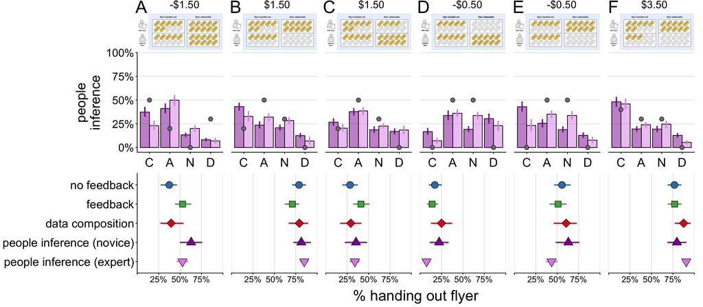

```r
set.seed(1)

# scenarios A-F in the figure, in terms of the manuscript's trial ordering
trial_selection = c(8, 18, 17, 10, 11, 22)

# maps the manuscript's trial ordering (sorted by expected benefit) onto the raw
# trial index used in the data
df.trial_images = df.trial_mapping %>%
  filter(trial_ordered %in% trial_selection) %>%
  mutate(trial_ordered = factor(trial_ordered, levels = trial_selection))

df.plot = df.exp3.long %>%
  select(-response) %>%
  pivot_longer(cols = c("compliers", "always", "never", "defiers"),
               names_to = "type",
               values_to = "value") %>%
  mutate(condition = "novice",
         participant = as.character(participant)) %>%
  bind_rows(df.exp5.long %>%
              select(-response) %>%
              mutate(condition = "expert")) %>%
  mutate(condition = factor(condition, levels = c("novice", "expert"))) %>%
  left_join(df.trial_images,
            by = "trial") %>%
  filter(trial_ordered %in% trial_selection) %>%
  select(-order) %>%
  mutate(type = factor(type, levels = c("compliers",
                                        "always",
                                        "never",
                                        "defiers",
                                        "flyer"))) %>%
  na.omit()

df.model = df.exp3.benefits %>%
  pivot_longer(cols = c("compliers", "always", "never", "defiers"),
               names_to = "type",
               values_to = "value") %>%
  mutate(trial = as.factor(trial)) %>%
  left_join(df.trial_images,
            by = "trial") %>%
  filter(trial_ordered %in% trial_selection) %>%
  mutate(condition = NA)

fun.load_image = function(t){
  readPNG(str_c("../../figures/trials/trial", t, ".png"))
}

# linking images and worlds
df.images = df.plot %>%
  distinct(trial, trial_ordered) %>%
  arrange(trial_ordered) %>%
  mutate(grob = map(.x = as.character(trial_ordered), .f = ~ fun.load_image(t = .x))) %>%
  mutate(condition = NA)

df.text = df.plot %>%
  distinct(trial, trial_ordered) %>%
  arrange(trial_ordered) %>%
  mutate(x = 1,
         y = Inf,
         condition = NA,
         label = LETTERS[1:nrow(.)])

df.text2 = df.exp3.model %>%
  select(trial, benefit = cf_mean) %>%
  left_join(df.trial_images,
            by = "trial") %>%
  filter(trial_ordered %in% trial_selection) %>%
  arrange(trial_ordered) %>%
  mutate(label = dollar_format()(benefit),
         x = 2,
         condition = NA,
         y = Inf)

# FIRST PLOT: people inferences
p1 = ggplot(data = df.plot,
            mapping = aes(x = type,
                          y = value,
                          group = condition,
                          color = condition,
                          fill = condition)) +
  stat_summary(fun = "mean",
               geom = "bar",
               color = "black",
               alpha = 0.5,
               position = position_dodge(0.9)) +
  stat_summary(fun.data = "mean_cl_boot",
               geom = "linerange",
               linewidth = 1,
               position = position_dodge(0.9)) +
  geom_point(data = df.model,
             mapping = aes(x = type,
                           y = value),
             size = 3,
             shape = 21,
             color="black") +
  geom_custom(data = df.images,
              mapping = aes(data = grob,
                            x = -Inf,
                            y = Inf),
              grob_fun = function(x) rasterGrob(x,
                                                interpolate = T,
                                                vjust = -0.05,
                                                hjust = 0)) +
  geom_text(data = df.text,
            mapping = aes(x = x,
                          y = y,
                          label = label),
            size = 10,
            vjust = -3.2,
            color = "black",
            hjust = 1.2) +
  geom_text(data = df.text2,
            mapping = aes(x = x,
                          y = y,
                          label = label),
            color = "black",
            size = 6,
            vjust = -6,
            hjust = 0) +
  scale_fill_manual(values = c("novice" = "#8E13A1", "expert" = "#DF8FEB")) +
  scale_color_manual(values = c("novice" = "#8E13A1", "expert" = "#DF8FEB")) +
  facet_wrap(~ trial_ordered,
             nrow = 1) +
  coord_cartesian(clip = "off") +
  labs(y = "people\ninference") +
  scale_size_manual(values = c(0.5, 1.5)) +
  scale_y_continuous(breaks = seq(0, 100, 25),
                     labels = str_c(seq(0, 100, 25), "%"),
                     limits = c(0, 100),
                     expand = expansion(add = c(5, 0))) +
  scale_x_discrete(labels = c("C", "A", "N", "D")) +
  theme(panel.grid.major.y = element_line(color = "gray90"),
        axis.text.y = element_text(size = 18),
        axis.text.x = element_text(size = 20,
                                   vjust = 0),
        axis.title.x = element_blank(),
        axis.title.y = element_text(vjust = -35,
                                    size = 22),
        legend.position = "none",
        strip.background = element_blank(),
        strip.text = element_blank(),
        panel.spacing.x = unit(0.5, "cm"),
        plot.margin = margin(t = 2.75, l = 0.5, r = 0.5, b = 0.2, unit = "cm"))

# SECOND PLOT: decisions
df.plot = df.exp1.long %>% mutate(experiment = "no feedback") %>%
  bind_rows(df.exp2.long %>% mutate(experiment = "feedback")) %>%
  bind_rows(df.exp3.long %>% mutate(experiment = "people inference (novice)")) %>%
  bind_rows(df.exp4.long %>% mutate(experiment = "data composition")) %>%
  bind_rows(df.exp5.long %>% mutate(experiment = "people inference (expert)") %>%
              select(-participant)) %>%
  mutate(experiment = factor(experiment,
                             levels = c("no feedback",
                                        "feedback",
                                        "data composition",
                                        "people inference (novice)",
                                        "people inference (expert)"))) %>%
  left_join(df.trial_images,
            by = "trial") %>%
  filter(trial_ordered %in% trial_selection)

p2 = ggplot(data = df.plot,
            mapping = aes(x = experiment,
                          y = response,
                          shape = experiment,
                          group = experiment,
                          fill = experiment,
                          color = experiment)) +
  stat_summary(fun.data = "mean_cl_boot",
               size = 1,
               geom = "linerange",
               position = position_dodge(width = 0.5)) +
  stat_summary(fun.data = "mean_cl_boot",
               size = 5,
               geom = "point",
               color = "black",
               position = position_dodge(width = 0.5)) +
  facet_wrap(~ trial_ordered,
             nrow = 1) +
  coord_flip(ylim = c(0, 1)) +
  labs(x = "condition",
       y = "% handing out flyer") +
  scale_x_discrete(limits = rev) +
  scale_y_continuous(
    breaks = seq(0, 1, 0.25),
    labels = c("", "25%", "50%", "75%", ""),
    limits = c(0, 1),
    expand = c(0, 0)) +
  scale_shape_manual(values = c("no feedback" = 21,
                                "feedback" = 22,
                                "data composition" = 23,
                                "people inference (novice)" = 24,
                                "people inference (expert)" = 25)) +
  scale_fill_manual(values = c("no feedback" = "#377EB8",
                                "feedback" = "#4DAF4A",
                                "data composition" = "#E41A1C",
                                "people inference (novice)" = "#8E13A1",
                                "people inference (expert)" = "#DF8FEB")) +
  scale_color_manual(values = c("no feedback" = "#377EB8",
                                "feedback" = "#4DAF4A",
                                "data composition" = "#E41A1C",
                                "people inference (novice)" = "#8E13A1",
                                "people inference (expert)" = "#DF8FEB") ) +
  theme(axis.title.x = element_text(margin = margin(t = 10)),
        axis.text.x = element_text(size = 14),
        axis.title.y = element_blank(),
        legend.position = "none",
        panel.grid.major.x = element_line(color = "gray90"),
        panel.spacing.x = unit(0.5, "cm"),
        plot.margin = margin(t = 0.2, l = 0.5, r = 0.5, b = 0, "cm"),
        strip.background = element_blank(),
        strip.text = element_blank())
p1 + p2 +
  plot_layout(ncol = 1) &
  plot_annotation(theme = theme(
    plot.margin = margin(l = -2, t = 0.3, r = 0, b = 0.2, unit = "cm"),
    panel.spacing = unit(0.1, "cm")
  ))

ggsave(file = "../../figures/plots/trial_selection.pdf",
       width = 16,
       height = 7)
```

## 5.3 Bonuses

### 5.3.1 Bonus per condition

> “Participants’ average bonus exceeded the chance level in both the `no feedback' condition (Mean = 0.51, 95% confidence interval = [0.37, 0.64]) and the`feedback’ condition (0.55, [0.44, 0.68]).”

and, for Experiment 2,

> “In the `people inference' condition, participants' average bonus was 0.81 [0.62, 0.99], and in the`data composition’ condition, it was 0.89 [0.69, 1.08].”

```r
df.experiment_bonuses = tibble(
  experiment = c(rep("1", times = length(df.exp1.bonuses$bonus_no_cap)),
                 rep("2", times = length(df.exp2.bonuses$bonus_no_cap)),
                 rep("3", times = length(df.exp3.bonuses$bonus_no_cap)),
                 rep("4", times = length(df.exp4.bonuses$bonus_no_cap)),
                 rep("5", times = length(df.exp5.bonuses$bonus_no_cap))),
  bonus = c(df.exp1.bonuses$bonus,
            df.exp2.bonuses$bonus,
            df.exp3.bonuses$bonus,
            df.exp4.bonuses$bonus,
            df.exp5.bonuses$bonus),
  bonus_no_cap = c(df.exp1.bonuses$bonus_no_cap,
                   df.exp2.bonuses$bonus_no_cap,
                   df.exp3.bonuses$bonus_no_cap,
                   df.exp4.bonuses$bonus_no_cap,
                   df.exp5.bonuses$bonus_no_cap)) %>%
  mutate(experiment = as.factor(experiment))

df.bonuses = df.experiment_bonuses %>%
  mutate(participant = 1:n(),
         experiment = factor(experiment,
                             levels = c(1, 2, 4, 3, 5),
                             labels = c("no feedback",
                                        "feedback",
                                        "data composition",
                                        "people inference (novice)",
                                        "people inference (expert)")))

# mean bonus with 95% bootstrapped CI per condition (reported in text)
df.bonuses %>%
  group_by(experiment) %>%
  reframe(value = smean.cl.boot(bonus_no_cap),
          name = c("mean", "low", "high")) %>%
  pivot_wider() %>%
  ungroup() %>%
  print_table()
```

| experiment | mean | low | high |
| --- | --- | --- | --- |
| no feedback | 0.51 | 0.38 | 0.64 |
| feedback | 0.56 | 0.44 | 0.68 |
| data composition | 0.89 | 0.68 | 1.09 |
| people inference (novice) | 0.81 | 0.64 | 0.99 |
| people inference (expert) | 1.31 | 1.17 | 1.46 |

### 5.3.2 Percent of participants above the random baseline

> “In the `no feedback' condition, 62% of participants received a bonus above the chance level, and 64% in the`feedback’ condition.”

```r
df.bonuses %>%
  mutate(above_baseline = bonus_no_cap > 0.325) %>%
  count(experiment, above_baseline) %>%
  group_by(experiment) %>%
  mutate(percentage = (n / sum(n)) * 100) %>%
  filter(above_baseline) %>%
  select(experiment, percentage) %>%
  print_table(digits = 0)
```

| experiment | percentage |
| --- | --- |
| no feedback | 62 |
| feedback | 64 |
| data composition | 81 |
| people inference (novice) | 80 |
| people inference (expert) | 98 |

### 5.3.3 Figure 3: Distribution of final bonus scores

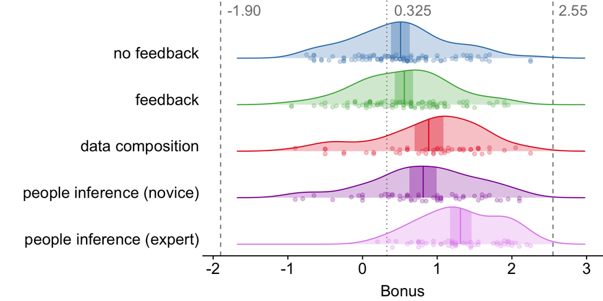

```r
set.seed(1)

colors = c("#377EB8", "#4DAF4A", "#E41A1C", "#8E13A1", "#DF8FEB")

bonus_range = c(-1.9, 0.325, 2.55)

plot = ggplot(data = df.bonuses,
              mapping = aes(x = bonus_no_cap,
                            y = experiment)) +
  geom_vline(xintercept = bonus_range,
             linetype = c("dashed", "dotted", "dashed"),
             color = "gray50",
             linewidth = 0.5) +
  geom_density_ridges(mapping = aes(color = experiment,
                                    fill = experiment),
                      bandwidth = 0.242,
                      jittered_points = TRUE,
                      position = position_points_jitter(height = 0.075,
                                                        width = 0),
                      scale = 0.8,
                      alpha = 0.25,
                      panel_scaling = F,
                      quantile_lines = TRUE,
                      quantile_fun = function(bonus_no_cap,...){mean(bonus_no_cap)}) +
  annotate(geom = "text",
           x = c(2.55, 0.325, -1.9),
           y = rep(5, 3),
           color = "gray50",
           label = c("2.55", "0.325", "-1.90"),
           vjust = -4,
           hjust = -0.2,
           size = 5) +
  scale_fill_manual(values = colors) +
  scale_color_manual(values = colors) +
  scale_y_discrete(limits = rev,
                   expand = expansion(add = c(0.25, 1.25))) +
  labs(x = "Bonus",
       y = "") +
  coord_cartesian(clip = "off") +
  theme_ridges(grid = F) +
  theme(legend.position = "none",
        axis.line.x = element_line(color = "black",
                                   linewidth = 0.5),
        axis.title.x = element_text(hjust = 0.5,
                                    size = 15),
        axis.text = element_text(size = 15),
        plot.margin = margin(l = 0, unit = "cm"))

# bootstrapped 95% CIs of the mean per condition
df.bonuses.ci = df.bonuses %>%
  group_by(experiment) %>%
  reframe(value = smean.cl.boot(bonus_no_cap),
          name = c("mean", "low", "high")) %>%
  pivot_wider()

# take the computed density curves so that the CI ribbons end exactly on them
df.ci_ribbons = layer_data(plot, i = 2) %>%
  filter(datatype == "ridgeline") %>%
  mutate(experiment = factor(levels(df.bonuses$experiment)[group],
                             levels = levels(df.bonuses$experiment))) %>%
  left_join(df.bonuses.ci,
            by = "experiment") %>%
  group_by(experiment) %>%
  reframe(x_ci = c(first(low), x[x > first(low) & x < first(high)], first(high)),
          ymax = approx(x, ymax, xout = x_ci)$y,
          ymin = first(ymin)) %>%
  rename(x = x_ci)

# insert the CI ribbons underneath the densities (drawn on top of the
# semi-transparent density fill, so they appear as a darker shade)
plot$layers = append(plot$layers,
                     list(geom_ribbon(data = df.ci_ribbons,
                                      mapping = aes(x = x,
                                                    ymin = ymin,
                                                    ymax = ymax,
                                                    fill = experiment),
                                      inherit.aes = FALSE,
                                      alpha = 0.35)),
                     after = 1)

plot

ggsave(file = "../../figures/plots/bonuses.pdf",
       width = 8,
       height = 4)
```

## 5.4 Percentage of correct decisions (bottom row of Table 1)

```r
set.seed(1)

df.percentage_correct = df.exp1.long %>%
  mutate(condition = "No feedback") %>%
  bind_rows(df.exp2.long %>%
              mutate(condition = "Feedback")) %>%
  left_join(df.exp1.model %>%
              select(trial, optimal_decision),
            by = "trial") %>%
  bind_rows(df.exp3.long %>%
              mutate(condition = "People inference") %>%
              bind_rows(df.exp4.long %>%
                          mutate(condition = "Data composition")) %>%
              left_join(df.exp3.model %>%
                          select(trial, optimal_decision),
                        by = "trial") %>%
              select(-c(always, compliers, defiers, never))) %>%
  mutate(participant = as.character(participant)) %>%
  bind_rows(df.exp5.long %>%
              distinct(participant, trial, response) %>%
              mutate(condition = "Experts") %>%
              left_join(df.exp5.model %>%
                          select(trial, optimal_decision),
                        by = "trial")) %>%
  mutate(correct = response == optimal_decision)

df.percentage_correct %>%
  group_by(condition, participant) %>%
  summarize(correct = mean(correct)) %>%
  group_by(condition) %>%
  reframe(value = smean.cl.boot(correct),
          name = c("mean", "low", "high")) %>%
  ungroup() %>%
  pivot_wider() %>%
  mutate(condition = factor(condition, levels = c("No feedback",
                                                  "Feedback",
                                                  "Data composition",
                                                  "People inference",
                                                  "Experts"))) %>%
  arrange(condition) %>%
  mutate(across(-condition,
                ~ .*100)) %>%
  print_table(digits = 0)
```

| condition | mean | low | high |
| --- | --- | --- | --- |
| No feedback | 54 | 51 | 56 |
| Feedback | 55 | 53 | 57 |
| Data composition | 59 | 55 | 62 |
| People inference | 58 | 55 | 62 |
| Experts | 66 | 64 | 69 |

## 5.5 Bias to hand out the flyer

> “Participants were more likely to hand out the flyer than not, both in the `no feedback' condition (56%, [53%, 58%]) and in the`feedback’ condition (56%, [54%, 58%]).” (and 54% / 57% in Experiment 2)

```r
df.percentage_correct %>%
  group_by(condition) %>%
  reframe(value = smean.cl.boot(response),
          name = c("mean", "low", "high")) %>%
  pivot_wider() %>%
  mutate(condition = factor(condition, levels = c("No feedback",
                                                  "Feedback",
                                                  "People inference",
                                                  "Data composition",
                                                  "Experts")),
         across(-condition, ~ .*100)) %>%
  arrange(condition) %>%
  print_table(digits = 0)
```

| condition | mean | low | high |
| --- | --- | --- | --- |
| No feedback | 56 | 54 | 58 |
| Feedback | 56 | 54 | 58 |
| People inference | 54 | 51 | 57 |
| Data composition | 57 | 54 | 59 |
| Experts | 54 | 51 | 57 |

## 5.6 Improvement over time in the feedback conditions

> “Participants’ likelihood of making the correct decision did not change as a function of trial number, 0.00 [-0.01, 0.01].” (Experiment 1, `feedback`)

> “There was neither an effect of trial number on whether a decision was correct in the `people inference' condition, -0.02 [-0.03, 0.00], nor in the`data composition’ condition, -0.01 [-0.03, 0.01].” (Experiment 2)

```r
df.model = df.exp2.long %>%
  left_join(df.exp2.model %>%
              select(trial, optimal_decision),
            by = "trial") %>%
  mutate(correct = 1*(response == optimal_decision))

brm.exp2.improvement = brm(correct ~ 1 + order + (1 + order | participant),
                           data = df.model,
                           family = bernoulli(),
                           cores = 4,
                           seed = 1,
                           control = list(adapt_delta = 0.99),
                           file = "models/exp2_improvement")

df.model = df.exp3.long %>%
  left_join(df.exp3.model %>%
              select(trial, optimal_decision),
            by = "trial") %>%
  mutate(correct = 1*(response == optimal_decision))

brm.exp3.improvement = brm(correct ~ 1 + order + (1 + order | participant),
                           data = df.model,
                           family = bernoulli(),
                           cores = 4,
                           seed = 1,
                           control = list(adapt_delta = 0.99),
                           file = "models/exp3_improvement")

df.model = df.exp4.long %>%
  left_join(df.exp3.model %>%
              select(trial, optimal_decision),
            by = "trial") %>%
  mutate(correct = 1*(response == optimal_decision))

brm.exp4.improvement = brm(correct ~ 1 + order + (1 + order | participant),
                           data = df.model,
                           family = bernoulli(),
                           cores = 4,
                           seed = 1,
                           control = list(adapt_delta = 0.99),
                           file = "models/exp4_improvement")

bind_rows(brm.exp2.improvement %>%
            tidy() %>%
            filter(term == "order") %>%
            select(estimate, conf.low, conf.high) %>%
            mutate(name = "feedback"),
          brm.exp3.improvement %>%
            tidy() %>%
            filter(term == "order") %>%
            select(estimate, conf.low, conf.high) %>%
            mutate(name = "people inference"),
          brm.exp4.improvement %>%
            tidy() %>%
            filter(term == "order") %>%
            select(estimate, conf.low, conf.high) %>%
            mutate(name = "data composition")) %>%
  relocate(name) %>%
  print_table()
```

| name | estimate | conf.low | conf.high |
| --- | --- | --- | --- |
| feedback | 0.00 | -0.01 | 0.01 |
| people inference | -0.02 | -0.04 | 0.00 |
| data composition | -0.01 | -0.03 | 0.01 |

## 5.7 Table 1: Trial information and participant decisions

The `*` / `#` suffixes mark whether the majority made the correct (green in the manuscript) or incorrect (red) decision.

```r
# round parentheses: scenarios in Figure 2; square brackets: examples in Figure 6
df.selection = tibble(trial_ordered = c(8, 18, 17, 10, 11, 22),
                      labels = LETTERS[1:6])

df.examples = tibble(trial_ordered = c(2, 11, 1, 10, 7, 17),
                     examples = LETTERS[1:6])

df.table_trial_selection = df.exp5.model %>%
  select(trial, pydox, pydoxp, pyx, pyxp, cf_mean) %>%
  left_join(df.exp3.benefits %>%
              mutate(across(.cols = -trial,
                            .fns = ~ . / 100)) %>%
              relocate(compliers, always, never, defiers) %>%
              mutate(trial = as.factor(trial)),
            by = "trial") %>%
  relocate(benefit = cf_mean, .after = last_col()) %>%
  left_join(df.exp1.long %>%
              group_by(trial) %>%
              summarize(`no feedback` = mean(response)),
            by = "trial") %>%
  left_join(df.exp2.long %>%
              group_by(trial) %>%
              summarize(`feedback` = mean(response)),
            by = "trial") %>%
  left_join(df.exp4.long %>%
              group_by(trial) %>%
              summarize(`data composition` = mean(response)),
            by = "trial") %>%
  left_join(df.exp3.long %>%
              group_by(trial) %>%
              summarize(`people inference (novice)` = mean(response)),
            by = "trial") %>%
  left_join(df.exp5.long %>%
              group_by(trial) %>%
              summarize(`people inference (expert)` = mean(response)),
            by = "trial") %>%
  left_join(df.trial_mapping,
            by = "trial") %>%
  left_join(df.selection,
            by = "trial_ordered") %>%
  left_join(df.examples,
            by = "trial_ordered") %>%
  relocate(trial_ordered, .before = trial) %>%
  arrange(trial_ordered) %>%
  mutate(trial_ordered = str_c(trial_ordered,
                               ifelse(!is.na(labels), str_c(" (", labels, ")"), ""),
                               ifelse(!is.na(labels) & !is.na(examples), ",", ""),
                               ifelse(!is.na(examples), str_c(" [", examples, "]"), ""))) %>%
  select(-c(trial, labels, examples)) %>%
  rename(trial = trial_ordered) %>%
  mutate(across(.cols = c(`no feedback`,
                          `feedback`,
                          `data composition`,
                          `people inference (novice)`,
                          `people inference (expert)`),
                .fns = ~ ifelse((sign(benefit) == -1 & . <= 0.5) |
                                (sign(benefit) == 1 & . >= 0.5),
                                str_c(format(round(., 2), nsmall = 2),"*"),
                                str_c(format(round(., 2), nsmall = 2),"#"))))

df.table_trial_selection %>%
  print_table(digits = 2)
```

| trial | pydox | pydoxp | pyx | pyxp | compliers | always | never | defiers | benefit | no feedback | feedback | data composition | people inference (novice) | people inference (expert) |
| --- | --- | --- | --- | --- | --- | --- | --- | --- | --- | --- | --- | --- | --- | --- |
| 1 [C] | 0.5 | 0.5 | 0.0 | 0.0 | 0.50 | 0.00 | 0.00 | 0.50 | -5.5 | 0.64# | 0.54# | 0.29* | 0.24* | 0.06* |
| 2 [A] | 0.5 | 0.5 | 1.0 | 1.0 | 0.50 | 0.00 | 0.00 | 0.50 | -5.5 | 0.20* | 0.30* | 0.17* | 0.46* | 0.09* |
| 3 | 0.5 | 0.4 | 0.0 | 0.0 | 0.50 | 0.00 | 0.10 | 0.40 | -3.5 | 0.58# | 0.51# | 0.50* | 0.35* | 0.36* |
| 4 | 0.6 | 0.5 | 0.2 | 0.0 | 0.50 | 0.10 | 0.00 | 0.40 | -3.5 | 0.66# | 0.60# | 0.52# | 0.46* | 0.47* |
| 5 | 0.6 | 0.5 | 1.0 | 1.0 | 0.50 | 0.10 | 0.00 | 0.40 | -3.5 | 0.41* | 0.44* | 0.38* | 0.54# | 0.32* |
| 6 | 0.6 | 0.4 | 0.2 | 0.0 | 0.55 | 0.05 | 0.05 | 0.35 | -2.0 | 0.73# | 0.68# | 0.73# | 0.46* | 0.57# |
| 7 [E] | 0.7 | 0.5 | 0.4 | 0.0 | 0.50 | 0.20 | 0.00 | 0.30 | -1.5 | 0.78# | 0.78# | 0.81# | 0.69# | 0.66# |
| 8 (A) | 0.7 | 0.5 | 1.0 | 1.0 | 0.50 | 0.20 | 0.00 | 0.30 | -1.5 | 0.37* | 0.53# | 0.40* | 0.63# | 0.53# |
| 9 | 0.5 | 0.3 | 0.0 | 0.0 | 0.50 | 0.00 | 0.20 | 0.30 | -1.5 | 0.61# | 0.56# | 0.65# | 0.28* | 0.57# |
| 10 (D), [D] | 0.5 | 0.5 | 0.0 | 1.0 | 0.00 | 0.50 | 0.50 | 0.00 | -0.5 | 0.17* | 0.14* | 0.25* | 0.22* | 0.08* |
| 11 (E), [B] | 0.5 | 0.5 | 1.0 | 0.0 | 0.00 | 0.50 | 0.50 | 0.00 | -0.5 | 0.56# | 0.51# | 0.60# | 0.63# | 0.43* |
| 12 | 0.5 | 0.4 | 1.0 | 0.0 | 0.10 | 0.40 | 0.50 | 0.00 | 0.5 | 0.55* | 0.59* | 0.67* | 0.76* | 0.79* |
| 13 | 0.6 | 0.5 | 0.2 | 1.0 | 0.10 | 0.50 | 0.40 | 0.00 | 0.5 | 0.18# | 0.25# | 0.29# | 0.26# | 0.11# |
| 14 | 0.6 | 0.5 | 1.0 | 0.0 | 0.10 | 0.50 | 0.40 | 0.00 | 0.5 | 0.71* | 0.71* | 0.73* | 0.67* | 0.74* |
| 15 | 0.5 | 0.2 | 0.0 | 0.0 | 0.50 | 0.00 | 0.30 | 0.20 | 0.5 | 0.66* | 0.59* | 0.62* | 0.30# | 0.68* |
| 16 | 0.6 | 0.4 | 1.0 | 0.0 | 0.20 | 0.40 | 0.40 | 0.00 | 1.5 | 0.74* | 0.74* | 0.73* | 0.72* | 0.81* |
| 17 (C), [F] | 0.7 | 0.5 | 0.4 | 1.0 | 0.20 | 0.50 | 0.30 | 0.00 | 1.5 | 0.28# | 0.41# | 0.29# | 0.35# | 0.34# |
| 18 (B) | 0.7 | 0.5 | 1.0 | 0.0 | 0.20 | 0.50 | 0.30 | 0.00 | 1.5 | 0.79* | 0.71* | 0.79* | 0.81* | 0.85* |
| 19 | 0.5 | 0.3 | 1.0 | 0.0 | 0.20 | 0.30 | 0.50 | 0.00 | 1.5 | 0.62* | 0.62* | 0.77* | 0.72* | 0.81* |
| 20 | 0.7 | 0.3 | 1.0 | 0.6 | 0.60 | 0.10 | 0.10 | 0.20 | 1.5 | 0.61* | 0.68* | 0.65* | 0.80* | 0.85* |
| 21 | 0.5 | 0.2 | 1.0 | 0.0 | 0.30 | 0.20 | 0.50 | 0.00 | 2.5 | 0.66* | 0.65* | 0.75* | 0.63* | 0.87* |
| 22 (F) | 0.7 | 0.3 | 1.0 | 0.0 | 0.40 | 0.30 | 0.30 | 0.00 | 3.5 | 0.77* | 0.77* | 0.88* | 0.80* | 0.91* |

## 5.8 Figure 4: Model predictions vs. decisions

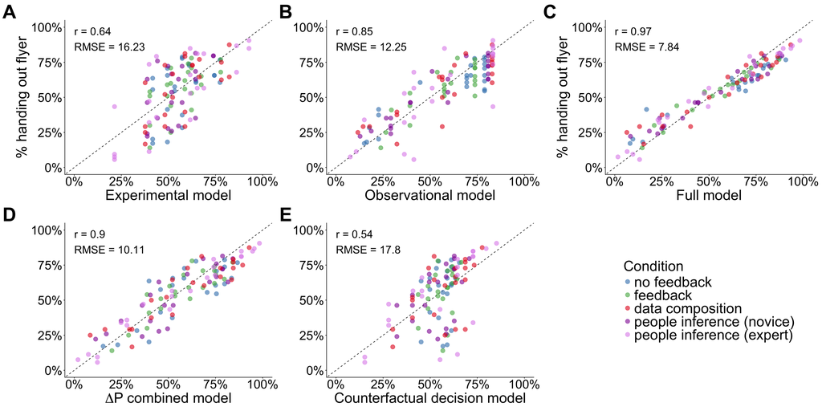

```r
df.exp1.regression_bayesian$experiment = "no feedback"
df.exp2.regression_bayesian$experiment = "feedback"
df.exp3.regression_bayesian$experiment = "people inference (novice)"
df.exp4.regression_bayesian$experiment = "data composition"
df.exp5.regression_bayesian$experiment = "people inference (expert)"

df.plot = bind_rows(df.exp1.regression_bayesian,
                    df.exp2.regression_bayesian,
                    df.exp3.regression_bayesian,
                    df.exp4.regression_bayesian,
                    df.exp5.regression_bayesian) %>%
  mutate(experiment = factor(experiment, levels = c("no feedback",
                                                    "feedback",
                                                    "data composition",
                                                    "people inference (novice)",
                                                    "people inference (expert)")))

fun.scatterplot = function(prediction, data, xtitle, ytitle, legend){
  plot = ggplot(data = data,
                mapping = aes(x = get(prediction),
                              y = response,
                              color = experiment)) +
    geom_abline(intercept = 0,
                slope = 1,
                linetype = "dashed",
                color = "black") +
    geom_point(alpha = 0.6,
               size = 4) +
    annotate(geom = "text",
             x = 0,
             y = 1,
             label = paste("r =", round(cor(data[[prediction]], data$response), 2),
                           "\nRMSE =", round(sqrt(mean((data[[prediction]] - data$response)^2))*100, 2)),
             hjust = 0,
             vjust = 1,
             size = 8,
             color = "black") +
    labs(x = xtitle,
         y = "% handing out flyer",
         color = "Condition") +
    scale_color_manual(values = c("no feedback" = "#377EB8",
                                  "feedback" = "#4DAF4A",
                                  "people inference (novice)" = "#8E13A1",
                                  "data composition" = "#E41A1C",
                                  "people inference (expert)" = "#DF8FEB")) +
    scale_x_continuous(breaks = seq(0, 1, 0.25),
                       limits = c(0, 1),
                       labels = percent) +
    scale_y_continuous(breaks = seq(0, 1, 0.25),
                       limits = c(0, 1),
                       labels = percent) +
    theme(axis.title.x = element_text(hjust = 0.5, size = 30),
          axis.title.y = element_text(hjust = 0.5, size = 30),
          axis.text = element_text(size = 26),
          plot.margin = margin(r = 0.5, unit = "cm"),
          legend.text = element_text(size = 30),
          legend.title = element_text(size = 30))

  if(!ytitle){
    plot = plot +
      theme(axis.title.y = element_blank())
  }
  if(!legend){
    plot = plot +
      theme(legend.position = "none")
  }

  return(plot)
}

plot_1 = fun.scatterplot(prediction = "experimental_data",
                         data = df.plot,
                         xtitle = "Experimental model",
                         ytitle = T,
                         legend = F)

plot_2 = fun.scatterplot(prediction = "observational_data",
                         data = df.plot,
                         xtitle = "Observational model",
                         ytitle = F,
                         legend = F)

plot_3 = fun.scatterplot(prediction = "strength_all",
                         data = df.plot,
                         xtitle = "Full model",
                         ytitle = T,
                         legend = F)

plot_4 = fun.scatterplot(prediction = "strength_both",
                         data = df.plot,
                         xtitle = expression(Delta*P~"combined model"),
                         ytitle = F,
                         legend = F)

plot_5 = fun.scatterplot(prediction = "usm",
                         data = df.plot,
                         xtitle = "Counterfactual decision model",
                         ytitle = F,
                         legend = T)

plot_1 + plot_2 + plot_3 + plot_4 + plot_5 + guide_area() +
  plot_layout(ncol = 3,
              guides = "collect") &
  plot_annotation(tag_levels = "A") &
  theme(plot.tag = element_text(face = "bold",
                                size = 40))

ggsave("../../figures/plots/model_scatter.pdf",
        width = 24,
        height = 12)
```

## 5.9 Table 3: Model comparison

$r$ and RMSE are computed on the trial means from the posterior means of the mixed effects models; $\Delta$elpd comes from `loo_compare()`.

```r
fun.model_comparison = function(df.regression,
                                fit.full, fit.observational, fit.deltap,
                                fit.experimental, fit.cdm){
  df.regression %>%
    select(trial, response) %>%
    bind_cols(fit.full %>%
                fitted(newdata = df.regression, re_formula = NA) %>%
                as_tibble() %>%
                select(full = Estimate)) %>%
    bind_cols(fit.observational %>%
                fitted(newdata = df.regression, re_formula = NA) %>%
                as_tibble() %>%
                select(observational = Estimate)) %>%
    bind_cols(fit.deltap %>%
                fitted(newdata = df.regression %>%
                         mutate(strength_observation_brm = pyx - pyxp,
                                strength_experiment_brm = pydox - pydoxp),
                       re_formula = NA) %>%
                as_tibble() %>%
                select(deltap = Estimate)) %>%
    bind_cols(fit.experimental %>%
                fitted(newdata = df.regression, re_formula = NA) %>%
                as_tibble() %>%
                select(experimental = Estimate)) %>%
    bind_cols(fit.cdm %>%
                fitted(newdata = df.regression, re_formula = NA) %>%
                as_tibble() %>%
                select(usm = Estimate)) %>%
    summarize(across(.cols = -c(trial, response),
                     .fns = list(r = ~ cor(., response),
                                 rmse = ~ sqrt(mean((. - response)^2))))) %>%
    pivot_longer(cols = everything(),
                 names_to = c("model", "name"),
                 names_sep = "_") %>%
    pivot_wider() %>%
    mutate(across(.cols = c(r, rmse),
                  .fns = ~ round(., 2))) %>%
    left_join(loo_compare(fit.cdm,
                          fit.deltap,
                          fit.full,
                          fit.observational,
                          fit.experimental) %>%
                as_tibble(rownames = "model") %>%
                mutate(model = factor(model,
                                      levels = c("fit.experimental",
                                                 "fit.observational",
                                                 "fit.full",
                                                 "fit.deltap",
                                                 "fit.cdm"),
                                      labels = c("experimental",
                                                 "observational",
                                                 "full",
                                                 "deltap",
                                                 "usm"))) %>%
                select(model, elpd_diff, se_diff) %>%
                mutate(across(.cols = -model,
                              .fns = ~ round(., 1))) %>%
                mutate(delta_elpd = str_c(elpd_diff, " (", se_diff, ")")) %>%
                select(model, delta_elpd),
              by = "model") %>%
    mutate(model = factor(model,
                          levels = c("experimental",
                                     "observational",
                                     "full",
                                     "deltap",
                                     "usm"))) %>%
    arrange(model)
}

df.model_comparison.no_feedback = fun.model_comparison(
  df.exp1.regression_bayesian,
  fit.exp1.strength_all_brm, fit.exp1.observational_data_brm,
  fit.exp1.strength_both_brm, fit.exp1.experimental_data_brm, fit.exp1.usm_brm)

df.model_comparison.feedback = fun.model_comparison(
  df.exp2.regression_bayesian,
  fit.exp2.strength_all_brm, fit.exp2.observational_data_brm,
  fit.exp2.strength_both_brm, fit.exp2.experimental_data_brm, fit.exp2.usm_brm)

df.model_comparison.people_inference_novice = fun.model_comparison(
  df.exp3.regression_bayesian,
  fit.exp3.strength_all_brm, fit.exp3.observational_data_brm,
  fit.exp3.strength_both_brm, fit.exp3.experimental_data_brm, fit.exp3.usm_brm)

df.model_comparison.data_composition = fun.model_comparison(
  df.exp4.regression_bayesian,
  fit.exp4.strength_all_brm, fit.exp4.observational_data_brm,
  fit.exp4.strength_both_brm, fit.exp4.experimental_data_brm, fit.exp4.usm_brm)

df.model_comparison.people_inference_expert = fun.model_comparison(
  df.exp5.regression_bayesian,
  fit.exp5.strength_all_brm, fit.exp5.observational_data_brm,
  fit.exp5.strength_both_brm, fit.exp5.experimental_data_brm, fit.exp5.usm_brm)

df.model_comparison.no_feedback %>%
  rename_with(.cols = -model,
              .fn = ~ str_c("no_feedback_", .)) %>%
  left_join(df.model_comparison.feedback %>%
              rename_with(.cols = -model,
                          .fn = ~ str_c("feedback_", .)),
            by = "model") %>%
  left_join(df.model_comparison.data_composition %>%
              rename_with(.cols = -model,
                          .fn = ~ str_c("data_composition_", .)),
            by = "model") %>%
  left_join(df.model_comparison.people_inference_novice %>%
              rename_with(.cols = -model,
                          .fn = ~ str_c("people_inference_novice_", .)),
            by = "model") %>%
  left_join(df.model_comparison.people_inference_expert %>%
              rename_with(.cols = -model,
                          .fn = ~ str_c("people_inference_expert_", .)),
            by = "model") %>%
  mutate(across(.cols = ends_with("_r"),
                .fns = ~ rd(., digits = 2))) %>%
  arrange(model) %>%
  print_table(format = "latex")
```

[output not shown]

## 5.10 Footnote: how well can the CDM be approximated by a linear model?

> “Even if all five free parameters in the `full’ model are fitted, it still only correlates $r = .71$ with the predictions of the CDM.”

$r$ is the square root of $R^2$ from regressing the normative expected benefit on the four probabilities.

```r
fit.cdm_from_data = lm(formula = cf_mean ~ 1 + pydox + pydoxp + pyx + pyxp,
                       data = df.exp1.model)

tibble(r.squared = summary(fit.cdm_from_data)$r.squared) %>%
  mutate(r = sqrt(r.squared)) %>%
  print_table()
```

| r.squared | r |
| --- | --- |
| 0.51 | 0.71 |

# 6 EXPERIMENT 2: Inferring counterfactual types before making decisions

## 6.1 Participants

```r
df.exp3and4.demographics = bind_rows(
  df.exp3.demographics %>% mutate(experiment = "people inference (novice)"),
  df.exp4.demographics %>% mutate(experiment = "data composition"))

df.exp3and4.demographics %>% count(experiment) %>% print_table()
```

| experiment | n |
| --- | --- |
| data composition | 48 |
| people inference (novice) | 54 |

```r
df.exp3and4.demographics %>%
  summarize(n = n(),
            age.mean = mean(age, na.rm = T),
            age.sd = sd(age, na.rm = T)) %>%
  print_table()
```

| n | age.mean | age.sd |
| --- | --- | --- |
| 102 | 35.78 | 11.93 |

```r
df.exp3and4.demographics %>%
    count(gender) %>%
    print_table()
```

| gender | n |
| --- | --- |
| Female | 56 |
| Male | 42 |
| Non-binary | 2 |
| NA | 2 |

```r
df.exp3and4.demographics %>%
  count(race) %>%
  print_table()
```

| race | n |
| --- | --- |
| Asian | 10 |
| Black/African American | 6 |
| White | 84 |
| hispanic | 1 |
| NA | 1 |

```r
df.exp3and4.demographics %>%
  summarize(duration.mean = mean(time / 60000, na.rm = T),
            duration.sd = sd(time / 60000, na.rm = T)) %>%
  print_table()
```

| duration.mean | duration.sd |
| --- | --- |
| 29.33 | 14.16 |

## 6.2 Table 4 (top panel): Predictors of novices’ people inferences

Separate Bayesian linear mixed effects models per person type. $r$ and RMSE are computed on trial means.

```r
df.model = df.exp3.model %>%
  select(trial, pyx, pyxp, pydox, pydoxp) %>%
  mutate(across(.cols = -trial,
                .fns = ~ scale(.)))

df.inferences = df.exp3.response_long %>%
  select(participant, trial, type, value) %>%
  left_join(df.model, by = "trial")

brm.inferences.compliers = brm(value ~ 1 + pyx + pyxp + pydox + pydoxp + (1 | participant),
  data = df.inferences %>% filter(type == "compliers"),
  family = gaussian(),
  cores = 4,
  seed = 1,
  file = "models/inferences_compliers")

brm.inferences.always = brm(value ~ 1 + pyx + pyxp + pydox + pydoxp + (1 | participant),
  data = df.inferences %>% filter(type == "always"),
  family = gaussian(),
  cores = 4,
  seed = 1,
  file = "models/inferences_always")

brm.inferences.never = brm(value ~ 1 + pyx + pyxp + pydox + pydoxp + (1 | participant),
  data = df.inferences %>% filter(type == "never"),
  family = gaussian(),
  cores = 4,
  seed = 1,
  file = "models/inferences_never")

brm.inferences.defiers = brm(value ~ 1 + pyx + pyxp + pydox + pydoxp + (1 | participant),
  data = df.inferences %>% filter(type == "defiers"),
  family = gaussian(),
  cores = 4,
  seed = 1,
  file = "models/inferences_defiers")

# Compute r and RMSE for trial means
df.means = df.inferences %>%
  group_by(trial, type) %>%
  summarize(data = mean(value)) %>%
  ungroup()

df.predictions = brm.inferences.compliers %>%
  fitted(newdata = df.model, re_formula = NA) %>%
  as_tibble() %>%
  mutate(trial = 1:n()) %>%
  select(trial, compliers = Estimate) %>%
  left_join(brm.inferences.always %>%
              fitted(newdata = df.model,
                     re_formula = NA) %>%
              as_tibble() %>%
              mutate(trial = 1:n()) %>%
              select(trial, always = Estimate),
            by = "trial") %>%
  left_join(brm.inferences.never %>%
              fitted(newdata = df.model, re_formula = NA) %>%
              as_tibble() %>%
              mutate(trial = 1:n()) %>%
              select(trial, never = Estimate),
            by = "trial") %>%
  left_join(brm.inferences.defiers %>%
              fitted(newdata = df.model, re_formula = NA) %>%
              as_tibble() %>%
              mutate(trial = 1:n()) %>%
              select(trial, defiers = Estimate),
            by = "trial") %>%
  pivot_longer(cols = c(compliers, always, never, defiers),
               names_to = "type",
               values_to = "prediction") %>%
  mutate(trial = as.factor(trial))

df.combined = df.means %>%
  left_join(df.predictions, by = c("trial", "type")) %>%
  group_by(type) %>%
  summarize(r = cor(data, prediction),
            rmse = sqrt(mean((data - prediction)^2)))

bind_rows(brm.inferences.compliers %>%
            tidy() %>%
            mutate(person = "compliers"),
          brm.inferences.always %>%
            tidy() %>%
            mutate(person = "always"),
          brm.inferences.never %>%
            tidy() %>%
            mutate(person = "never"),
          brm.inferences.defiers %>%
            tidy() %>%
            mutate(person = "defiers")) %>%
  filter(effect == "fixed") %>%
  select(person, term, estimate, conf.low, conf.high) %>%
  mutate(across(c(estimate, conf.low, conf.high),
                ~ format(round(., 2), trim = T, digits = 2, nsmall = 2)),
         label = str_c(estimate, " [", conf.low, ", ", conf.high, "]")) %>%
  select(person, term, label) %>%
  pivot_wider(names_from = term, values_from = label) %>%
  left_join(df.combined, by = c("person" = "type")) %>%
  relocate(pyx, pyxp, .after = pydoxp) %>%
  print_table(digits = 2)
```

| person | (Intercept) | pydox | pydoxp | pyx | pyxp | r | rmse |
| --- | --- | --- | --- | --- | --- | --- | --- |
| compliers | 33.27 [30.89, 35.88] | 1.81 [0.88, 2.79] | -0.62 [-1.61, 0.39] | 8.91 [8.00, 9.84] | -2.90 [-3.91, -1.92] | 0.98 | 2.04 |
| always | 27.34 [25.03, 29.56] | -0.63 [-1.54, 0.29] | 2.32 [1.37, 3.28] | 1.21 [0.33, 2.08] | 6.74 [5.81, 7.63] | 0.98 | 1.74 |
| never | 23.99 [21.87, 26.15] | -0.20 [-1.08, 0.67] | -1.79 [-2.64, -0.94] | -5.89 [-6.69, -5.07] | -4.18 [-5.05, -3.29] | 0.95 | 2.45 |
| defiers | 15.21 [13.41, 17.00] | -1.00 [-1.70, -0.30] | 0.09 [-0.61, 0.80] | -4.22 [-4.91, -3.52] | 0.34 [-0.38, 1.05] | 0.86 | 2.67 |

## 6.3 Footnote: linear models predicting the normative person types

> “$r(\text{complier}) = 0.47$, $r(\text{always-goer}) = 0.50$, $r(\text{never-goer}) = 0.50$, $r(\text{defier}) = 0.42$”

```r
df.exp3.model %>%
  left_join(df.exp3.benefits %>%
              mutate(trial = as.factor(trial)),
            by = "trial") %>%
  select(trial, contains("py"), always:never) %>%
  pivot_longer(cols = always:never) %>%
  group_by(name) %>%
  nest() %>%
  mutate(fit = map(.x = data,
                   .f = ~ lm(formula = value ~ 1 + pydox + pydoxp + pyx + pyxp,
                             data = .)),
         summary = map(.x = fit, .f = ~ glance(.))) %>%
  ungroup() %>%
  select(name, summary) %>%
  unnest(summary) %>%
  select(name, r.squared) %>%
  mutate(r = r.squared ^ (1/2)) %>%
  print_table()
```

| name | r.squared | r |
| --- | --- | --- |
| always | 0.25 | 0.50 |
| compliers | 0.23 | 0.47 |
| defiers | 0.17 | 0.42 |
| never | 0.25 | 0.50 |

## 6.4 Correlation between normative and actual people inferences

> “The correlation between the CDM’s predictions and participants’ inferences was $r = .11$ [$-.10, .31$].”

```r
df.people_inference = df.exp3.long %>%
  pivot_longer(cols = c(always, compliers, defiers, never),
               names_to = "people",
               values_to = "value") %>%
  group_by(trial, people) %>%
  summarize(data = mean(value)) %>%
  ungroup() %>%
  left_join(df.exp3.benefits_long %>%
              select(trial, people = variable, prediction = value) %>%
              mutate(trial = as.factor(trial)),
            by = c("trial", "people"))

cor.test(df.people_inference$data, df.people_inference$prediction)
```

```
    Pearson's product-moment correlation

data:  df.people_inference$data and df.people_inference$prediction
t = 1.0158, df = 86, p-value = 0.3126
alternative hypothesis: true correlation is not equal to 0
95 percent confidence interval:
 -0.1029073  0.3112266
sample estimates:
      cor
0.1088817
```

## 6.5 Figure 5: People inference vs. decisions

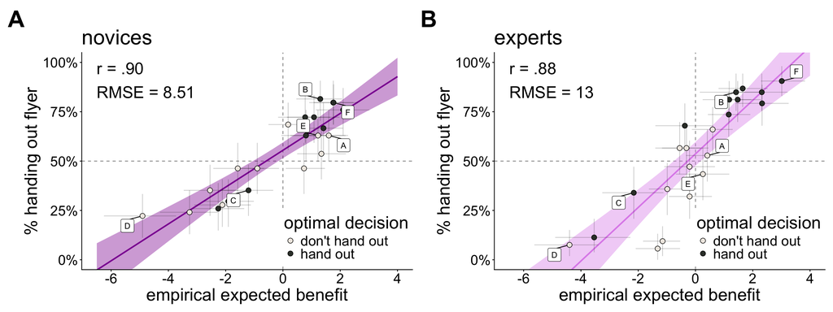

```r
set.seed(1)

df.trial_selection = tibble(trial_ordered = c(8, 18, 17, 10, 11, 22),
                            label = LETTERS[1:6])

df.trial_labels = df.trial_mapping %>%
  left_join(df.trial_selection,
            by = "trial_ordered") %>%
  select(-trial_ordered) %>%
  mutate(trial = factor(trial))

# Plot 1: novices
df.plot = df.exp3.long %>%
  mutate(across(.cols = c(compliers, always, never, defiers),
                .fns = ~ ./100)) %>%
  mutate(empirical_benefit = compliers * 9.50 +
           always * (-0.50) + never * (-0.50) + defiers * (-20.50)) %>%
  group_by(trial) %>%
  reframe(value = smean.cl.boot(empirical_benefit),
          name = c("benefit_mean", "benefit_low", "benefit_high")) %>%
  pivot_wider() %>%
  left_join(df.exp3.long %>%
              group_by(trial) %>%
              reframe(value = smean.cl.boot(response),
                      name = c("decision_mean", "decision_low", "decision_high")) %>%
              pivot_wider(),
            by = "trial") %>%
  ungroup() %>%
  left_join(df.exp3.model %>%
              select(trial, optimal_decision),
            by = "trial") %>%
  mutate(optimal_decision = factor(optimal_decision,
                                   levels = c(0, 1),
                                   labels = c("don't hand out", "hand out"))) %>%
  left_join(df.trial_labels,
            by = "trial")

fit = lm(formula = decision_mean ~ 1 + benefit_mean,
         data = df.plot)

text.r = rd(cor(df.plot$benefit_mean,
           df.plot$decision_mean), 2)

text.rmse = fit %>%
  augment() %>%
  summarize(100*sqrt(mean(.resid^2))) %>%
  round(2) %>%
  as.double()

p1 = ggplot(data = df.plot,
              mapping = aes(x = benefit_mean,
                            y = decision_mean)) +
  geom_hline(yintercept = 0.5,
             linetype = "dashed",
             alpha = 0.5) +
  geom_vline(xintercept = 0,
             linetype = "dashed",
             alpha = 0.5) +
  geom_smooth(method = "lm",
              formula = y ~ x,
              color = "#8E13A1",
              fill = "#8E13A1",
              fullrange = T) +
  geom_linerange(mapping = aes(ymin = decision_low,
                               ymax = decision_high),
                 color = "black",
                 alpha = 0.2) +
  geom_linerange(mapping = aes(xmin = benefit_low,
                               xmax = benefit_high),
                 color = "black",
                 alpha = 0.2) +
  geom_point(mapping = aes(fill = optimal_decision),
             size = 3,
             shape = 21) +
  geom_label_repel(mapping = aes(label = label),
                   size = 4,
                   box.padding = 0.7,
                   label.padding = unit(0.35, "lines"),
                   point.padding = 0.3,
                   min.segment.length = 0) +
  annotate(geom = "text",
           x = -6.5,
           y = 1,
           label = str_c("r = ", text.r,
                         "\nRMSE = ", text.rmse),
           hjust = 0,
           vjust = 1,
           size = 8) +
  labs(x = "empirical expected benefit",
       y = "% handing out flyer",
       fill = "optimal decision",
       title = "novices") +
  coord_cartesian(ylim = c(0, 1)) +
  scale_x_continuous(breaks = seq(-6, 4, 2),
                     limits = c(-6.5, 4)) +
  scale_y_continuous(breaks = seq(0, 1, by = 0.25),
                     labels = percent_format(scale = 100)) +
  scale_fill_manual(values = c("#f0eae4", "#363b35")) +
  theme(legend.position = c(0.8, 0.15))

# Plot 2: experts
df.plot = df.exp5.long %>%
  pivot_wider(names_from = type,
                values_from = value) %>%
  mutate(across(.cols = c(compliers, always, never, defiers),
                .fns = ~ ./100)) %>%
  mutate(empirical_benefit = compliers * 9.50 +
           always * (-0.50) + never * (-0.50) + defiers * (-20.50)) %>%
  group_by(trial) %>%
  reframe(value = smean.cl.boot(empirical_benefit),
          name = c("benefit_mean", "benefit_low", "benefit_high")) %>%
  pivot_wider() %>%
  left_join(df.exp5.long %>%
              pivot_wider(names_from = type,
                values_from = value) %>%
              group_by(trial) %>%
              reframe(value = smean.cl.boot(response),
                      name = c("decision_mean", "decision_low", "decision_high")) %>%
              pivot_wider(),
            by = "trial") %>%
  ungroup() %>%
  left_join(df.exp3.model %>%
              select(trial, optimal_decision),
            by = "trial") %>%
  mutate(optimal_decision = factor(optimal_decision,
                                   levels = c(0, 1),
                                   labels = c("don't hand out", "hand out"))) %>%
  left_join(df.trial_labels,
            by = "trial")

fit = lm(formula = decision_mean ~ 1 + benefit_mean,
         data = df.plot)

text.r = rd(cor(df.plot$benefit_mean,
           df.plot$decision_mean), 2)

text.rmse = fit %>%
  augment() %>%
  summarize(100*sqrt(mean(.resid^2))) %>%
  round(2) %>%
  as.double()

p2 = ggplot(data = df.plot,
              mapping = aes(x = benefit_mean,
                            y = decision_mean)) +
  geom_hline(yintercept = 0.5,
             linetype = "dashed",
             alpha = 0.5) +
  geom_vline(xintercept = 0,
             linetype = "dashed",
             alpha = 0.5) +
  geom_smooth(method = "lm",
              formula = y ~ x,
              color = "#DF8FEB",
              fill = "#DF8FEB",
              fullrange = T) +
  geom_linerange(mapping = aes(ymin = decision_low,
                               ymax = decision_high),
                 color = "black",
                 alpha = 0.2) +
  geom_linerange(mapping = aes(xmin = benefit_low,
                               xmax = benefit_high),
                 color = "black",
                 alpha = 0.2) +
  geom_point(mapping = aes(fill = optimal_decision),
             size = 3,
             shape = 21) +
  geom_label_repel(mapping = aes(label = label),
                   size = 4,
                   box.padding = 0.7,
                   label.padding = unit(0.35, "lines"),
                   point.padding = 0.3,
                   min.segment.length = 0) +
  annotate(geom = "text",
           x = -6.5,
           y = 1,
           label = str_c("r = ", text.r,
                         "\nRMSE = ", text.rmse),
           hjust = 0,
           vjust = 1,
           size = 8) +
  labs(x = "empirical expected benefit",
       y = "% handing out flyer",
       fill = "optimal decision",
       title = "experts") +
  coord_cartesian(ylim = c(0, 1))+
  scale_x_continuous(breaks = seq(-6, 4, 2),
                     limits = c(-6.5, 4)) +
  scale_y_continuous(labels = percent_format(scale = 100),
                     breaks = seq(0, 1, by = 0.25)) +
  scale_fill_manual(values = c("#f0eae4", "#363b35")) +
  theme(legend.position = c(0.8, 0.15))

p1 + p2 +
  plot_layout(ncol = 2) &
  plot_annotation(tag_levels = "A") &
  theme(plot.tag = element_text(face = "bold",
                                size = 32))

ggsave(file = "../../figures/plots/flyer_vs_expected_benefit.pdf",
       width = 16,
       height = 6)
```

# 7 EXPERIMENT 3: Expert judgments

## 7.1 Participants

```r
# age
df.exp5.demographics %>%
  mutate(age = as.numeric(age)) %>%
  summarize(n = n(),
            age.mean = mean(age),
            age.range = str_c(range(age)[1], "-", range(age)[2]),
            age.sd = sd(age)) %>%
  print_table()
```

| n | age.mean | age.range | age.sd |
| --- | --- | --- | --- |
| 53 | 23.25 | 18-33 | 4 |

```r
df.exp5.demographics %>% count(gender) %>% print_table()
```

| gender | n |
| --- | --- |
| Female | 26 |
| Male | 26 |
| other_gender | 1 |

```r
df.exp5.demographics %>% count(race) %>% print_table()
```

| race | n |
| --- | --- |
| Asian | 21 |
| Black/African American | 3 |
| White | 26 |
| other_race | 3 |

```r
df.exp5.demographics %>% count(ethnicity) %>% print_table()
```

| ethnicity | n |
| --- | --- |
| Hispanic | 3 |
| Non-Hispanic | 50 |

```r
df.exp5.demographics %>% count(department) %>% print_table()
```

| department | n |
| --- | --- |
| BioEngineering | 1 |
| Biology | 1 |
| Computer Science | 1 |
| Computer science | 1 |
| Econ | 1 |
| Economics | 24 |
| Economics | 1 |
| Engineering | 4 |
| Epidemiology and Population Health | 1 |
| Humanities | 1 |
| Humanities & Sciences / Engineering | 1 |
| Psychology | 1 |
| Psychology/Economics | 1 |
| Sociology | 1 |
| Stat | 1 |
| Statistics | 3 |
| Sustainability | 1 |
| Undecided | 3 |
| Vice Provost of Undergraduate Education | 1 |
| economics | 1 |
| humanities and sciences | 1 |
| psychology | 1 |
| social sciences | 1 |

```r
df.exp5.demographics %>% count(degree) %>% print_table()
```

| degree | n |
| --- | --- |
| Masters student | 1 |
| PhD student | 22 |
| Postdoc | 3 |
| Undergraduate student | 27 |

```r
df.exp5.demographics %>% count(causal_inference) %>% print_table()
```

| causal_inference | n |
| --- | --- |
| not at all | 11 |
| slightly | 15 |
| somewhat | 14 |
| very | 13 |

## 7.2 Are experts’ inferences more accurate than novices’?

```r
df.inference_difference = df.exp3.long %>%
  select(participant, trial, always, compliers, defiers, never) %>%
  pivot_longer(cols = c(always, compliers, defiers, never),
               names_to = "type") %>%
  mutate(experiment = "novice",
         participant = as.character(participant)) %>%
  bind_rows(df.exp5.long %>%
              select(participant, trial, type, value) %>%
              mutate(experiment = "expert")) %>%
  left_join(df.exp3.benefits %>%
              pivot_longer(cols = c(always, compliers, defiers, never),
                           names_to = "type",
                           values_to = "model") %>%
              mutate(trial = as.factor(trial)),
            by = c("trial", "type")) %>%
  mutate(type = factor(type,
                       levels = c("compliers", "always", "never", "defiers")),
         experiment = factor(experiment,
                             levels = c("novice", "expert"))) %>%
  arrange(participant, trial, type) %>%
  mutate(error = (value - model)^2)

fit.inference_difference_brm = brm(
  formula = error ~ 1 + experiment + (1 | participant),
  data = df.inference_difference,
  family = gaussian(),
  seed = 1,
  cores = 4,
  file = "models/inference_difference")

fit.inference_difference_brm %>%
  tidy() %>%
  select(effect, term, estimate, contains("conf")) %>%
  print_table()
```

| effect | term | estimate | conf.low | conf.high |
| --- | --- | --- | --- | --- |
| fixed | (Intercept) | 706.86 | 632.94 | 780.55 |
| fixed | experimentexpert | 101.20 | -3.34 | 199.77 |
| ran_pars | sd__(Intercept) | 248.20 | 210.04 | 292.99 |
| ran_pars | sd__Observation | 1026.20 | 1011.04 | 1041.43 |

## 7.3 Aggregate people inferences (input to Table B1 and the correlations below)

```r
df.exp5.people_inference = df.exp5.long %>%
  group_by(trial, type) %>%
  summarize(mean = mean(value)) %>%
  pivot_wider(names_from = type,
                          values_from = mean) %>%
              relocate(compliers, always, never, defiers) %>%
              rename_with(.col = -trial,
                          .fn = ~ str_c("expert_", .x))

df.aggregate_inferences = df.exp3.model %>%
  select(trial, pydox, pydoxp, pyx, pyxp, cf_mean) %>%
  left_join(df.exp3.long %>%
              select(participant, trial, always, compliers, defiers, never) %>%
              pivot_longer(cols = c(always, compliers, defiers, never),
                           names_to = "type") %>%
              group_by(type, trial) %>%
              summarize(mean = mean(value)) %>%
              ungroup() %>%
              pivot_wider(names_from = type,
                          values_from = mean) %>%
              relocate(compliers, always, never, defiers) %>%
              rename_with(.col = -trial,
                          .fn = ~ str_c("novice_", .x)),
            by = "trial") %>%
  left_join(df.exp5.people_inference,
            by = "trial") %>%
  left_join(df.exp3.benefits %>%
              relocate(compliers, always, never, defiers) %>%
              rename_with(.col = -trial,
                          .fn = ~ str_c("model_", .x)) %>%
              mutate(trial = as.factor(trial)),
            by = "trial") %>%
  relocate(contains("model"), .after = pyxp) %>%
  mutate(across(c(contains("model"), contains("novice"), contains("expert")),
                ~ ./100)) %>%
  mutate(novice_benefit = 9.5 * novice_compliers +
           (-0.5) * novice_always +
           (-0.5) * novice_never +
           (-20.5) * novice_defiers,
         expert_benefit = 9.5 * expert_compliers +
           (-0.5) * expert_always +
           (-0.5) * expert_never +
           (-20.5) * expert_defiers) %>%
  left_join(df.trial_mapping,
            by = "trial") %>%
  relocate(trial_ordered, .after = trial) %>%
  relocate(novice_benefit, .after = novice_defiers) %>%
  select(-trial) %>%
  arrange(trial_ordered)
```

## 7.4 Correlations between novice, expert, and normative inferences

> “Across all of the 22 trials, the novice and expert inferences were strongly correlated ($r = .75$, RMSE $= 0.08$), but expert inferences were less correlated with the normative inferences compared to novices (novices: $r = .11$, RMSE $= 0.22$; experts: $r = .06$, RMSE $= 0.23$).”

```r
df.inference_comparison = df.aggregate_inferences %>%
  select(trial_ordered, contains("model"), contains("novice"), contains("expert"), -contains("benefit")) %>%
  pivot_longer(cols = -trial_ordered,
               names_to = c("name", "type"),
               names_sep = "_") %>%
  pivot_wider()

df.inference_comparison %>%
  select(model, novice, expert) %>%
  summarize(rmse_model.novice = sqrt(mean((model - novice)^2)),
            rmse_model.expert = sqrt(mean((model - expert)^2)),
            rmse_novice.expert = sqrt(mean((novice - expert)^2)),
            r_model.novice = cor(model, novice),
            r_model.expert = cor(model, expert),
            r_novice.expert = cor(novice, expert)) %>%
  pivot_longer(cols = everything(),
               names_to = c("name", "model"),
               names_sep = "_") %>%
  pivot_wider() %>%
  print_table()
```

| model | rmse | r |
| --- | --- | --- |
| model.novice | 0.22 | 0.11 |
| model.expert | 0.23 | 0.06 |
| novice.expert | 0.08 | 0.75 |

## 7.5 Table 4 (bottom panel): Predictors of experts’ people inferences

```r
df.model = df.exp3.model %>%
              select(trial, pyx, pyxp, pydox, pydoxp) %>%
              mutate(across(.cols = -trial, .fns = ~ scale(.)))

df.inferences = df.exp5.long %>%
  select(participant, trial, type, value) %>%
  left_join(df.model, by = "trial")

brm.expert.inferences.compliers = brm(value ~ 1 + pyx + pyxp + pydox + pydoxp + (1 | participant),
  data = df.inferences %>% filter(type == "compliers"),
  family = gaussian(),
  cores = 4,
  seed = 1,
  file = "models/expert_inferences_compliers")

brm.expert.inferences.always = brm(value ~ 1 + pyx + pyxp + pydox + pydoxp + (1 | participant),
  data = df.inferences %>% filter(type == "always"),
  family = gaussian(),
  cores = 4,
  seed = 1,
  file = "models/expert_inferences_always")

brm.expert.inferences.never = brm(value ~ 1 + pyx + pyxp + pydox + pydoxp + (1 | participant),
  data = df.inferences %>% filter(type == "never"),
  family = gaussian(),
  cores = 4,
  seed = 1,
  file = "models/expert_inferences_never")

brm.expert.inferences.defiers = brm(value ~ 1 + pyx + pyxp + pydox + pydoxp + (1 | participant),
  data = df.inferences %>% filter(type == "defiers"),
  family = gaussian(),
  cores = 4,
  seed = 1,
  file = "models/expert_inferences_defiers")

# Compute r and RMSE for trial means
df.means = df.inferences %>% # nolint: assignment_linter.
  group_by(trial, type) %>%
  summarize(data = mean(value)) %>%
  ungroup()

df.predictions = brm.expert.inferences.compliers %>%
  fitted(newdata = df.model, re_formula = NA) %>%
  as_tibble() %>%
  mutate(trial = 1:n()) %>%
  select(trial, compliers = Estimate) %>%
  left_join(brm.expert.inferences.always %>%
              fitted(newdata = df.model, re_formula = NA) %>%
              as_tibble() %>%
              mutate(trial = 1:n()) %>%
              select(trial, always = Estimate),
            by = "trial") %>%
  left_join(brm.expert.inferences.never %>%
              fitted(newdata = df.model, re_formula = NA) %>%
              as_tibble() %>%
              mutate(trial = 1:n()) %>%
              select(trial, never = Estimate),
            by = "trial") %>%
  left_join(brm.expert.inferences.defiers %>%
              fitted(newdata = df.model, re_formula = NA) %>%
              as_tibble() %>%
              mutate(trial = 1:n()) %>%
              select(trial, defiers = Estimate),
            by = "trial") %>%
  pivot_longer(cols = c(compliers, always, never, defiers),
               names_to = "type",
               values_to = "prediction") %>%
  mutate(trial = as.factor(trial))

df.combined = df.means %>%
  left_join(df.predictions, by = c("trial", "type")) %>%
  group_by(type) %>%
  summarize(r = cor(data, prediction), rmse = sqrt(mean((data - prediction)^2)))

bind_rows(brm.expert.inferences.compliers %>%
            tidy() %>%
            mutate(person = "compliers"),
          brm.expert.inferences.always %>%
            tidy() %>%
            mutate(person = "always"),
          brm.expert.inferences.never %>%
            tidy() %>%
            mutate(person = "never"),
          brm.expert.inferences.defiers %>%
            tidy() %>%
            mutate(person = "defiers")) %>%
  filter(effect == "fixed") %>%
  select(person, term, estimate, conf.low, conf.high) %>%
  mutate(across(c(estimate, conf.low, conf.high),
                ~ format(round(., 2), trim = T, digits = 2, nsmall = 2)),
         label = str_c(estimate, " [", conf.low, ", ", conf.high, "]")) %>%
  select(person, term, label) %>%
  pivot_wider(names_from = term, values_from = label) %>%
  left_join(df.combined, by = c("person" = "type")) %>%
  relocate(pyx, pyxp, .after = pydoxp) %>%
  print_table(digits = 2)
```

| person | (Intercept) | pydox | pydoxp | pyx | pyxp | r | rmse |
| --- | --- | --- | --- | --- | --- | --- | --- |
| compliers | 24.92 [22.30, 27.42] | 4.43 [3.40, 5.48] | -5.11 [-6.18, -4.06] | 5.02 [3.97, 6.04] | -3.72 [-4.83, -2.64] | 0.94 | 3.58 |
| always | 32.02 [29.79, 34.31] | -0.95 [-1.89, -0.04] | 4.82 [3.81, 5.81] | 3.40 [2.47, 4.33] | 5.30 [4.33, 6.27] | 0.93 | 3.57 |
| never | 33.07 [30.51, 35.53] | -3.10 [-4.06, -2.15] | 0.30 [-0.70, 1.31] | -5.18 [-6.12, -4.22] | -4.58 [-5.55, -3.61] | 0.97 | 2.24 |
| defiers | 9.38 [7.04, 11.84] | -0.37 [-1.10, 0.40] | 0.00 [-0.76, 0.74] | -3.25 [-3.94, -2.56] | 3.00 [2.24, 3.76] | 0.83 | 2.90 |

# 8 Appendix

## 8.1 Table B1: People inferences for each trial

```r
df.aggregate_inferences %>%
  print_table()
```

| trial_ordered | pydox | pydoxp | pyx | pyxp | model_compliers | model_always | model_never | model_defiers | cf_mean | novice_compliers | novice_always | novice_never | novice_defiers | novice_benefit | expert_compliers | expert_always | expert_never | expert_defiers | expert_benefit |
| --- | --- | --- | --- | --- | --- | --- | --- | --- | --- | --- | --- | --- | --- | --- | --- | --- | --- | --- | --- |
| 1 | 0.5 | 0.5 | 0.0 | 0.0 | 0.50 | 0.00 | 0.00 | 0.50 | -5.5 | 0.18 | 0.28 | 0.31 | 0.23 | -3.26 | 0.10 | 0.30 | 0.50 | 0.09 | -1.32 |
| 2 | 0.5 | 0.5 | 1.0 | 1.0 | 0.50 | 0.00 | 0.00 | 0.50 | -5.5 | 0.32 | 0.43 | 0.15 | 0.10 | 0.74 | 0.09 | 0.55 | 0.29 | 0.08 | -1.15 |
| 3 | 0.5 | 0.4 | 0.0 | 0.0 | 0.50 | 0.00 | 0.10 | 0.40 | -3.5 | 0.20 | 0.21 | 0.39 | 0.20 | -2.55 | 0.18 | 0.23 | 0.47 | 0.12 | -0.98 |
| 4 | 0.6 | 0.5 | 0.2 | 0.0 | 0.50 | 0.10 | 0.00 | 0.40 | -3.5 | 0.28 | 0.23 | 0.33 | 0.16 | -0.90 | 0.20 | 0.33 | 0.39 | 0.08 | -0.21 |
| 5 | 0.6 | 0.5 | 1.0 | 1.0 | 0.50 | 0.10 | 0.00 | 0.40 | -3.5 | 0.35 | 0.43 | 0.13 | 0.09 | 1.34 | 0.19 | 0.51 | 0.23 | 0.08 | -0.21 |
| 6 | 0.6 | 0.4 | 0.2 | 0.0 | 0.55 | 0.05 | 0.05 | 0.35 | -2.0 | 0.27 | 0.21 | 0.33 | 0.19 | -1.58 | 0.21 | 0.27 | 0.41 | 0.11 | -0.55 |
| 7 | 0.7 | 0.5 | 0.4 | 0.0 | 0.50 | 0.20 | 0.00 | 0.30 | -1.5 | 0.35 | 0.24 | 0.28 | 0.14 | 0.18 | 0.25 | 0.32 | 0.36 | 0.07 | 0.60 |
| 8 | 0.7 | 0.5 | 1.0 | 1.0 | 0.50 | 0.20 | 0.00 | 0.30 | -1.5 | 0.37 | 0.41 | 0.13 | 0.08 | 1.60 | 0.23 | 0.50 | 0.20 | 0.07 | 0.41 |
| 9 | 0.5 | 0.3 | 0.0 | 0.0 | 0.50 | 0.00 | 0.20 | 0.30 | -1.5 | 0.22 | 0.20 | 0.38 | 0.19 | -2.12 | 0.23 | 0.21 | 0.46 | 0.10 | -0.32 |
| 10 | 0.5 | 0.5 | 0.0 | 1.0 | 0.00 | 0.50 | 0.50 | 0.00 | -0.5 | 0.17 | 0.34 | 0.19 | 0.30 | -4.90 | 0.07 | 0.36 | 0.34 | 0.23 | -4.40 |
| 11 | 0.5 | 0.5 | 1.0 | 0.0 | 0.00 | 0.50 | 0.50 | 0.00 | -0.5 | 0.43 | 0.25 | 0.19 | 0.13 | 1.22 | 0.23 | 0.35 | 0.34 | 0.08 | 0.26 |
| 12 | 0.5 | 0.4 | 1.0 | 0.0 | 0.10 | 0.40 | 0.50 | 0.00 | 0.5 | 0.47 | 0.23 | 0.19 | 0.11 | 2.10 | 0.40 | 0.25 | 0.30 | 0.06 | 2.32 |
| 13 | 0.6 | 0.5 | 0.2 | 1.0 | 0.10 | 0.50 | 0.40 | 0.00 | 0.5 | 0.24 | 0.37 | 0.19 | 0.21 | -2.26 | 0.18 | 0.32 | 0.26 | 0.24 | -3.54 |
| 14 | 0.6 | 0.5 | 1.0 | 0.0 | 0.10 | 0.50 | 0.40 | 0.00 | 0.5 | 0.42 | 0.25 | 0.22 | 0.11 | 1.41 | 0.29 | 0.33 | 0.31 | 0.06 | 1.16 |
| 15 | 0.5 | 0.2 | 0.0 | 0.0 | 0.50 | 0.00 | 0.30 | 0.20 | 0.5 | 0.22 | 0.19 | 0.41 | 0.18 | -1.91 | 0.23 | 0.18 | 0.48 | 0.11 | -0.37 |
| 16 | 0.6 | 0.4 | 1.0 | 0.0 | 0.20 | 0.40 | 0.40 | 0.00 | 1.5 | 0.41 | 0.25 | 0.22 | 0.13 | 1.09 | 0.33 | 0.30 | 0.30 | 0.07 | 1.47 |
| 17 | 0.7 | 0.5 | 0.4 | 1.0 | 0.20 | 0.50 | 0.30 | 0.00 | 1.5 | 0.27 | 0.38 | 0.19 | 0.17 | -1.20 | 0.20 | 0.39 | 0.23 | 0.18 | -2.15 |
| 18 | 0.7 | 0.5 | 1.0 | 0.0 | 0.20 | 0.50 | 0.30 | 0.00 | 1.5 | 0.43 | 0.24 | 0.21 | 0.13 | 1.30 | 0.33 | 0.32 | 0.28 | 0.07 | 1.42 |
| 19 | 0.5 | 0.3 | 1.0 | 0.0 | 0.20 | 0.30 | 0.50 | 0.00 | 1.5 | 0.42 | 0.20 | 0.24 | 0.15 | 0.78 | 0.32 | 0.26 | 0.33 | 0.08 | 1.18 |
| 20 | 0.7 | 0.3 | 1.0 | 0.6 | 0.60 | 0.10 | 0.10 | 0.20 | 1.5 | 0.43 | 0.29 | 0.18 | 0.10 | 1.77 | 0.41 | 0.30 | 0.22 | 0.07 | 2.32 |
| 21 | 0.5 | 0.2 | 1.0 | 0.0 | 0.30 | 0.20 | 0.50 | 0.00 | 2.5 | 0.41 | 0.20 | 0.25 | 0.14 | 0.80 | 0.36 | 0.21 | 0.35 | 0.07 | 1.65 |
| 22 | 0.7 | 0.3 | 1.0 | 0.0 | 0.40 | 0.30 | 0.30 | 0.00 | 3.5 | 0.48 | 0.20 | 0.19 | 0.13 | 1.76 | 0.46 | 0.24 | 0.25 | 0.05 | 3.01 |

## 8.2 Table C1: Performance differences between conditions

```r
brm.bonuses = brm(bonus_no_cap ~ experiment,
                  data = df.bonuses,
                  family = gaussian(),
                  seed = 1,
                  file = "models/bonuses")

brm.bonuses %>%
  emmeans(specs = pairwise ~ experiment) %>%
  summary(point.est = "mean") %>%
  .[["contrasts"]] %>%
  as_tibble() %>%
  print_table()
```

| contrast | estimate | lower.HPD | upper.HPD |
| --- | --- | --- | --- |
| no feedback - feedback | -0.05 | -0.23 | 0.12 |
| no feedback - data composition | -0.38 | -0.60 | -0.16 |
| no feedback - people inference (novice) | -0.30 | -0.51 | -0.09 |
| no feedback - people inference (expert) | -0.80 | -1.02 | -0.59 |
| feedback - data composition | -0.33 | -0.55 | -0.11 |
| feedback - people inference (novice) | -0.25 | -0.46 | -0.03 |
| feedback - people inference (expert) | -0.75 | -0.97 | -0.54 |
| data composition - people inference (novice) | 0.08 | -0.18 | 0.32 |
| data composition - people inference (expert) | -0.42 | -0.69 | -0.16 |
| people inference (novice) - people inference (expert) | -0.50 | -0.74 | -0.26 |

## 8.3 Table D1: Correlations between decisions across conditions

```r
condition_levels = c("No feedback",
                    "Feedback",
                    "Data composition",
                    "People inference",
                    "Experts")

condition_labels = c("No feedback",
                    "Feedback",
                    "Data composition",
                    "People inference (novice)",
                    "People inference (expert)")

bind_rows(df.exp1.long %>%
            mutate(condition = "No feedback"),
          df.exp2.long %>%
            mutate(condition = "Feedback"),
          df.exp3.long %>%
            mutate(condition = "People inference"),
          df.exp4.long %>%
            mutate(condition = "Data composition")) %>%
  mutate(participant = as.character(participant)) %>%
  bind_rows(df.exp5.long %>%
              mutate(condition = "Experts")) %>%
  group_by(condition, trial) %>%
  summarize(response = mean(response)) %>%
  mutate(condition = factor(condition,
                            levels = condition_levels,
                            labels = condition_labels)) %>%
  arrange(condition) %>%
  pivot_wider(names_from = condition,
              values_from = response) %>%
  select(-trial) %>%
  correlate(quiet = T) %>%
  shave() %>%
  slice_tail(n = 4) %>%
  select(-`People inference (expert)`) %>%
  fashion() %>%
  set_names(c("", condition_labels[-length(condition_labels)])) %>%
  print_table()
```

|  | No feedback | Feedback | Data composition | People inference (novice) |
| --- | --- | --- | --- | --- |
| Feedback | .94 |  |  |  |
| Data composition | .87 | .88 |  |  |
| People inference (novice) | .52 | .68 | .69 |  |
| People inference (expert) | .74 | .84 | .91 | .79 |

## 8.4 Table E1 and Table E2: Expert performance by degree and familiarity with causal inference

> “Finally, we explored whether there were any differences in performance in our expert sample based on their degree (Table E1), or their self-rated familiarity with causal inference (Table E2). We found no credible differences.”

```r
# Table E1: performance as a function of degree
df.exp5.bonuses %>%
  left_join(df.exp5.demographics %>%
              select(participant, degree),
            by = "participant") %>%
  mutate(degree = factor(degree, levels = c("Undergraduate student",
                                            "Masters student",
                                            "PhD student",
                                            "Postdoc"))) %>%
  group_by(degree) %>%
  reframe(value = smean.cl.boot(bonus),
          n = n(),
          name = c("mean", "low", "high")) %>%
  pivot_wider() %>%
  mutate(across(.cols = c(mean, low, high),
                .fns = ~ round(.x, 2))) %>%
  mutate(value = str_c(mean, " [", low, ", ", high, "]"),
         value = ifelse(is.na(value), mean, value)) %>%
  select(degree, n, value) %>%
  arrange(degree) %>%
  print_table()
```

| degree | n | value |
| --- | --- | --- |
| Undergraduate student | 27 | 1.36 [1.2, 1.54] |
| Masters student | 1 | 2 |
| PhD student | 22 | 1.26 [1.02, 1.47] |
| Postdoc | 3 | 1.03 [0.35, 1.8] |

```r
# Table E2: performance as a function of familiarity with causal inference
df.exp5.bonuses %>%
  left_join(df.exp5.expertise,
            by = "participant") %>%
  group_by(causal_inference) %>%
  reframe(value = smean.cl.boot(bonus),
          n = n(),
          name = c("mean", "low", "high")) %>%
  pivot_wider() %>%
  mutate(across(.cols = c(mean, low, high),
                .fns = ~ round(.x, 2))) %>%
  mutate(value = str_c(mean, " [", low, ", ", high, "]"),
         causal_inference = factor(causal_inference,
                                   levels = 1:4,
                                   labels = c("not at all", "slightly", "somewhat", "very"))) %>%
  select(causal_inference, n, value) %>%
  print_table()
```

| causal_inference | n | value |
| --- | --- | --- |
| not at all | 11 | 1.4 [1.18, 1.64] |
| slightly | 15 | 1.37 [1.09, 1.63] |
| somewhat | 14 | 1.12 [0.79, 1.45] |
| very | 13 | 1.37 [1.15, 1.6] |